# Gat201 RNA Seq deseq-analysis_2 2021-06-18EH

Liz Hughes

18/06/2021

# GAT201 RNA Seq analysis_EHughes

To carry out RNA-Seq I will use the Lexogen Quant Seq 3’ mRNA-Seq library prep kit FWD. This is designed to generate illumina compatible libraries of sequences close to the 3’ end of polyA RNA.

Work flow: Reverse transcription ⇒ Removal of RNA ⇒ Second strand synthesis ⇒ Library amplification ⇒ Sequencing

4 strains: KN99a, KN99 alpha, Gat201 deletion from the Madhani deletion collection (003) and Gat201 disruption from the Bahn collection (004).

2 conditions: RPMI and RPMI+Serum (10%).

2 BioReps and 3 Tech Reps.

A single colony was grown in YPD, 30 degrees, 200rpm for 5 days.

3.5 ml was transferred to 100ml fresh RPMI or RPMI+10% Serum and incubated at 37 degrees, 60rpm.

2ml samples were taken from each rep at time 0hrs, fix and freeze and put at -80 degrees.

At 30 mins, 2hrs and 4hrs 15 ml samples were collected, fix and freeze and put at -80 degrees.

# Load packages used for analysis

# Define colours for specific samples

```r
WTup_colour   = "orange"
WTdown_colour = "green"
Gat201up_colour  = "red"
Gat201down_colour = "blue"
```

# Load count data and remove unwanted parts of column names

```r
counts <- readr::read_tsv("~/Documents/GitHub/CryptoGat201RNASeq_draft/quantseqfwd_EH_050221/counts.txt",
                   comment = "#") %>%
          dplyr::rename_with(str_remove_all, pattern = "_S[0-9]+_R1_001_aln.bam")
```

# Load sample sheet and format for DESeq2’s requirements: readxl::read_excel

Connect sample names to informative data that generated the data.

Extra steps to format for DESeq2.

Remove all samples not sequenced: ‘dplyr::filter’

Remove notes in column: ‘dplyr::select’

Set rownames to make format of table appropriate for DESeq: ‘magrittr::set_rownames’

```r
samplesheet <- readxl::read_excel("~/Documents/GitHub/CryptoGat201RNASeq_draft/input_experiment/Gat201_samplesheet.xlsx") %>%
              magrittr::set_rownames(.$SampleID)%>%
              dplyr::mutate(GAT201 = forcats::fct_collapse(Strain, Yes = c("a","A"), No = c("B","M")))
```

We now have all the ingredients to prepare our data object in a form that is suitable for analysis, namely:

counts: a table with the read counts samplesheet: a table with information about the samples

# Differential expression analysis

## Gat201 deletion (GAT201 = no) v WT (GAT201 = yes) 0h only

```r
samplesheet_0h <- dplyr::filter(samplesheet, Time == "0")
                  print(samplesheet_0h)
```

```
## # A tibble: 8 x 9
##   SampleID BioRep Media Timepoint Group Strain Condition  Time GAT201
## * <chr>     <dbl> <chr>     <dbl> <chr> <chr>  <chr>     <dbl> <fct>
## 1 1             1 YPD           0 A_Y_0 A      Y             0 Yes
## 2 5b            2 YPD           0 A_Y_0 A      Y             0 Yes
## 3 15            1 YPD           0 a_Y_0 a      Y             0 Yes
## 4 19            2 YPD           0 a_Y_0 a      Y             0 Yes
## 5 29b           1 YPD           0 B_Y_0 B      Y             0 No
## 6 33            2 YPD           0 B_Y_0 B      Y             0 No
## 7 43            1 YPD           0 M_Y_0 M      Y             0 No
## 8 47            2 YPD           0 M_Y_0 M      Y             0 No
```

```r
counts_0h <-   dplyr::select(counts, samplesheet_0h$SampleID) %>%
               magrittr::set_rownames(counts$Geneid)

dds_0h <- DESeqDataSetFromMatrix(countData = counts_0h,
                                 colData = samplesheet_0h,
                                 design = ~ GAT201)%>%
        DESeq()

resultsNames(dds_0h)
```

```
## [1] "Intercept"        "GAT201_No_vs_Yes"
```

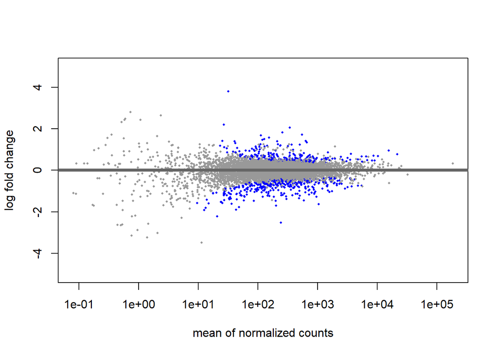

```r
results_0h <- results(dds_0h, name="GAT201_No_vs_Yes")
plotMA(results_0h, ylim=c(-5,5))
```

```r
tresults_0h <- biobroom::tidy.DESeqResults(results_0h)
head(tresults_0h)
```

```
## # A tibble: 6 x 7
##   gene       baseMean estimate stderror statistic    p.value p.adjusted
##   <chr>         <dbl>    <dbl>    <dbl>     <dbl>      <dbl>      <dbl>
## 1 CNAG_00002     397.   0.768     0.166     4.62  0.00000384   0.000397
## 2 CNAG_00003     242.   0.101     0.186     0.542 0.588        0.832
## 3 CNAG_00004     247.  -0.229     0.165    -1.39  0.165        0.494
## 4 CNAG_00005     377.  -0.0567    0.201    -0.282 0.778        0.916
## 5 CNAG_00006     969.   0.0392    0.175     0.224 0.822        0.935
## 6 CNAG_00007     102.  -0.215     0.190    -1.13  0.259        0.600
```

```r
tresults_0h %>%
dplyr::mutate(minus_log10_pvalue = -log10(p.value)) %>%
readr::write_tsv("~/Documents/GitHub/CryptoGat201RNASeq_draft/results_deseq_2/Gat201_WT_DEseq2_genes0h.txt")

de_Gat201up_0h <- dplyr::filter(tresults_0h, estimate > 1, p.adjusted < 0.05) %>%
              dplyr::arrange(desc(estimate))
de_Gat201up_0h
```

```
## # A tibble: 31 x 7
##    gene       baseMean estimate stderror statistic  p.value   p.adjusted
##    <chr>         <dbl>    <dbl>    <dbl>     <dbl>    <dbl>        <dbl>
##  1 CNAG_01560     32.0     3.80    1.16       3.29 1.01e- 3 0.0248
##  2 CNAG_02553     26.8     2.19    0.377      5.81 6.31e- 9 0.00000167
##  3 CNAG_01571    342.      2.05    0.590      3.47 5.23e- 4 0.0157
##  4 CNAG_01551    257.      1.82    0.313      5.82 5.86e- 9 0.00000166
##  5 CNAG_02225    547.      1.71    0.267      6.41 1.46e-10 0.0000000732
##  6 CNAG_01275    111.      1.68    0.288      5.82 5.86e- 9 0.00000166
##  7 CNAG_06484    152.      1.58    0.326      4.84 1.32e- 6 0.000168
##  8 CNAG_03754    127.      1.50    0.277      5.43 5.66e- 8 0.0000119
##  9 CNAG_07913     25.5     1.42    0.355      3.99 6.59e- 5 0.00340
## 10 CNAG_06568    628.      1.41    0.217      6.51 7.71e-11 0.0000000456
## # ... with 21 more rows
```

```r
readr::write_tsv(de_Gat201up_0h, "~/Documents/GitHub/CryptoGat201RNASeq_draft/results_deseq_2/Gat201up_DEseq2_padj0p05_0h.txt")
readr::write_lines(de_Gat201up_0h$gene, "~/Documents/GitHub/CryptoGat201RNASeq_draft/results_deseq_2/Gat201up_DEseq2_padj0p05_0h_genesonly.txt")

de_Gat201down_0h <- dplyr::filter(tresults_0h, estimate < -1, p.adjusted < 0.05) %>%
                dplyr::arrange(estimate)
de_Gat201down_0h
```

```
## # A tibble: 74 x 7
##    gene       baseMean estimate stderror statistic  p.value p.adjusted
##    <chr>         <dbl>    <dbl>    <dbl>     <dbl>    <dbl>      <dbl>
##  1 CNAG_00979    242.     -2.52    0.294     -8.58 9.50e-18   6.18e-14
##  2 CNAG_06802     20.7    -2.21    0.438     -5.04 4.56e- 7   6.74e- 5
##  3 CNAG_00472     12.6    -1.92    0.510     -3.76 1.73e- 4   7.15e- 3
##  4 CNAG_05962     42.7    -1.90    0.353     -5.39 7.15e- 8   1.45e- 5
##  5 CNAG_06662     13.2    -1.80    0.493     -3.66 2.55e- 4   9.32e- 3
##  6 CNAG_05144     48.3    -1.77    0.349     -5.07 4.04e- 7   6.26e- 5
##  7 CNAG_04681    202.     -1.70    0.234     -7.27 3.58e-13   5.82e-10
##  8 CNAG_07791   1039.     -1.64    0.490     -3.34 8.25e- 4   2.17e- 2
##  9 CNAG_02194     36.0    -1.61    0.339     -4.74 2.15e- 6   2.57e- 4
## 10 CNAG_01333     14.9    -1.60    0.408     -3.92 9.02e- 5   4.22e- 3
## # ... with 64 more rows
```

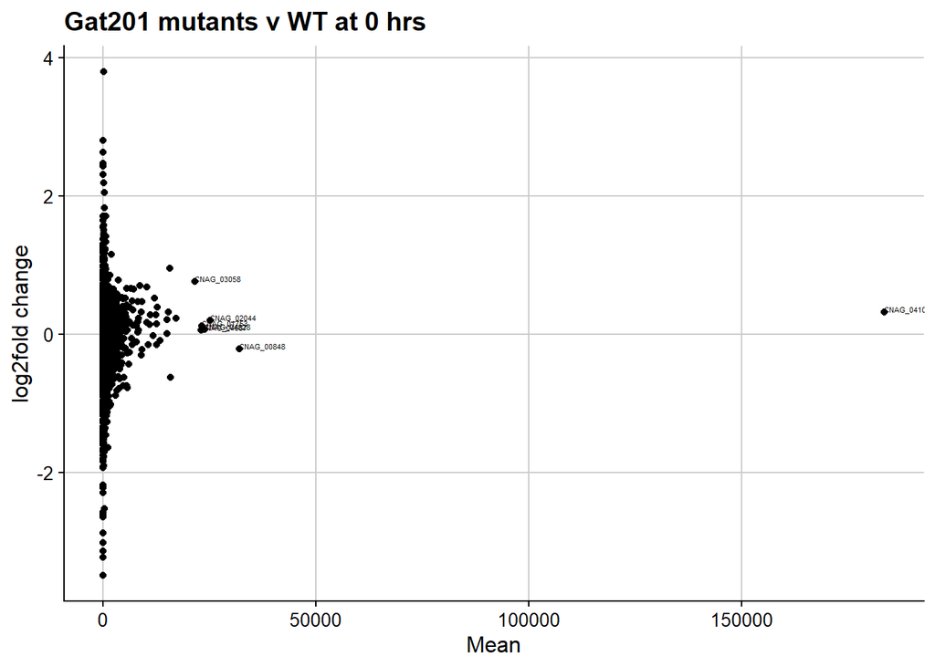

```r
readr::write_tsv(de_Gat201down_0h, "~/Documents/GitHub/CryptoGat201RNASeq_draft/results_deseq_2/Gat201down_DEseq2_padj0p05_0h.txt")
readr::write_lines(de_Gat201down_0h$gene, "~/Documents/GitHub/CryptoGat201RNASeq_draft/results_deseq_2/Gat201down_DEseq2_padj0p05_0h_genesonly.txt")

plot_0h<- qplot(x = baseMean, y = estimate, data = tresults_0h, geom = "point")+
               geom_text(aes(label=ifelse(baseMean> 20000, (gene),'')),hjust=0,vjust=0, cex = 1.5, jitter = 0.5)+
               labs(x ="Mean", y= "log2fold change", title = "Gat201 mutants v WT at 0 hrs")
plot_0h
```

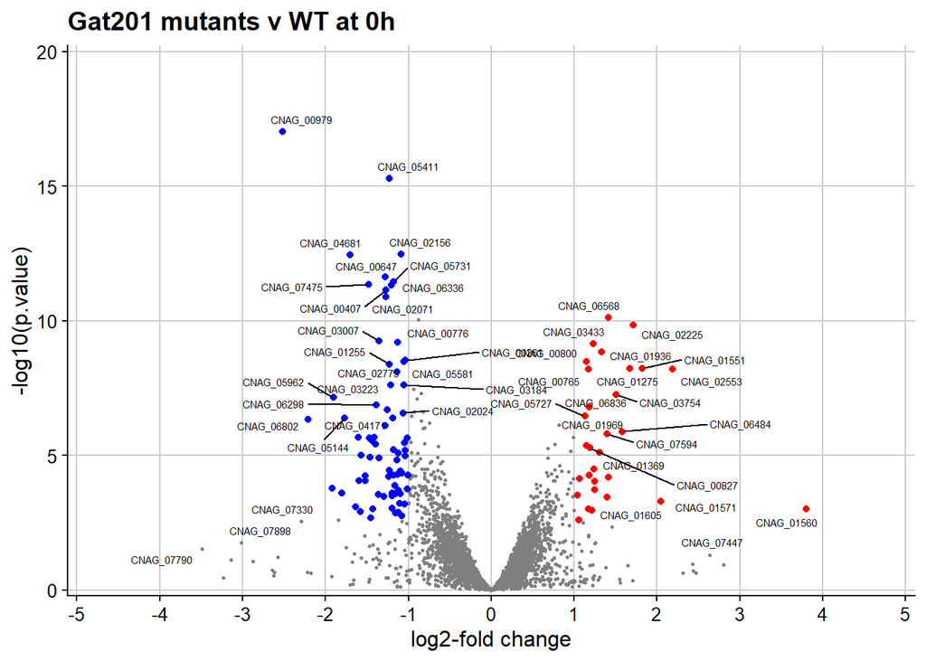

```r
volcano_0h <-
  ggplot(data = tresults_0h, aes(x=estimate,y=-log10(p.value))) +
         geom_point(colour = "grey50",size = 0.5) +
         geom_point(data = de_Gat201up_0h, colour = Gat201up_colour) +
         geom_point(data = de_Gat201down_0h, colour = Gat201down_colour) +

         geom_text_repel(aes(label=ifelse(estimate < -1 & -log10(p.value)> 1.3, (gene),'')), size= 2, max.overlaps = getOption("ggrepel.max.overlaps", default = 15))+
         geom_text_repel(aes(label=ifelse(estimate > 1 & -log10(p.value)> 1.3, (gene),'')), size = 2, max.overlaps = getOption("ggrepel.max.overlaps", default = 15))+

         scale_y_continuous(breaks = c(0,5,10,15,20),
                            limits = c(0,20),
                            expand = c(0.01,0.01),
                            oob = scales::squish) +
        scale_x_continuous(breaks = seq(-5,5,1),
                            limits = c(-5,5),
                            expand = c(0.01,0.01),
                            oob = scales::squish) +
        labs(x = "log2-fold change",
             y = "-log10(p.value)",
        title = "Gat201 mutants v WT at 0h")
volcano_0h
```

```r
ggsave("~/Documents/GitHub/CryptoGat201RNASeq_draft/results_deseq_2/Gat201vWT_0h_volcano.png",
       width = 5,height=5)
```

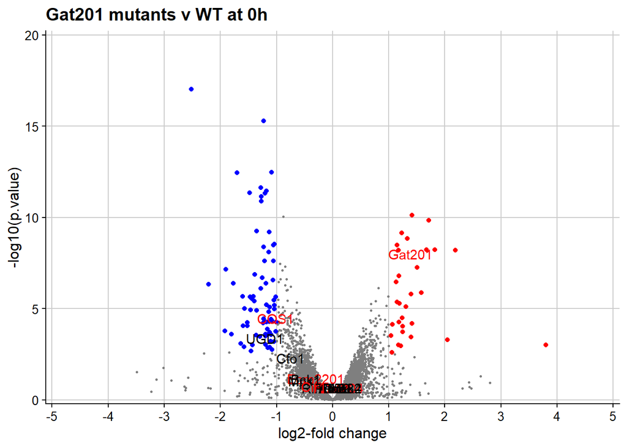

```r
volcano_0hsp <-
  ggplot(data = tresults_0h, aes(x=estimate,y=-log10(p.value))) +
         geom_point(colour = "grey50",size = 0.5) +
         geom_point(data = de_Gat201up_0h, colour = Gat201up_colour) +
         geom_point(data = de_Gat201down_0h, colour = Gat201down_colour) +
    geom_text_repel(data = filter(tresults_0h, gene =="CNAG_01551"), label="Gat201",hjust = 1.1,vjust = -0.1, colour= "red")+
    geom_text_repel(data = filter(tresults_0h, gene =="CNAG_06762"), label="Gat204",hjust = 1.1,vjust = -0.1, colour= "red")+
    geom_text_repel(data = filter(tresults_0h, gene =="CNAG_063641"), label="Blp1",hjust = 1.1,vjust = -0.1, colour= "red")+
    geom_text_repel(data = filter(tresults_0h, gene =="CNAG_00883"), label="Ecm2201",hjust = 1.1,vjust = -0.1, colour= "red")+
    geom_text_repel(data = filter(tresults_0h, gene =="CNAG_05835"), label="Liv3",hjust = 1.1,vjust = -0.1, colour= "red")+
    geom_text_repel(data = filter(tresults_0h, gene =="CNAG_03012"), label="CQS1",hjust = 1.1,vjust = -0.1, colour= "red")+
    geom_text_repel(data = filter(tresults_0h, gene =="CNAG_01681"), label="FCY2",hjust = 1.1,vjust = -0.1, colour= "red")+
    geom_text_repel(data = filter(tresults_0h, gene =="CNAG_06401"), label="Ric8",hjust = 1.1,vjust = -0.1, colour= "black")+
    geom_text_repel(data = filter(tresults_0h, gene =="CNAG_07470"), label="Pde2",hjust = 1.1,vjust = -0.1, colour= "black")+
    geom_text_repel(data = filter(tresults_0h, gene =="CNAG_06241"), label="Cfo1",hjust = 1.1,vjust = -0.1, colour= "black")+
    geom_text_repel(data = filter(tresults_0h, gene =="CNAG_02777"), label="Pho84",hjust = 1.1,vjust = -0.1, colour= "black")+
    geom_text_repel(data = filter(tresults_0h, gene =="CNAG_04755"), label="Bck1",hjust = 1.1,vjust = -0.1, colour= "black")+
    geom_text_repel(data = filter(tresults_0h, gene =="CNAG_02357"), label="Mkk2",hjust = 1.1,vjust = -0.1, colour= "black")+
    geom_text_repel(data = filter(tresults_0h, gene =="CNAG_04514"), label="Mpk1",hjust = 1.1,vjust = -0.1, colour= "black")+
    geom_text_repel(data = filter(tresults_0h, gene =="CNAG_04969"), label="UGD1",hjust = 1.1,vjust = -0.1, colour= "black")+
    geom_text_repel(data = filter(tresults_0h, gene =="CNAG_01626"), label="Ada2",hjust = 1.1,vjust = -0.1, colour= "black")+
    geom_text_repel(data = filter(tresults_0h, gene =="CNAG_03024"), label="Rim15",hjust = 1.1,vjust = -0.1, colour= "black")+
    geom_text_repel(data = filter(tresults_0h, gene =="CNAG_04864"), label="Cir1",hjust = 1.1,vjust = -0.1, colour= "red")+
         scale_y_continuous(breaks = c(0,5,10,15,20),
                            limits = c(0,20),
                            expand = c(0.01,0.01),
                            oob = scales::squish) +
        scale_x_continuous(breaks = seq(-5,5,1),
                            limits = c(-5,5),
                            expand = c(0.01,0.01),
                            oob = scales::squish) +
        labs(x = "log2-fold change",
             y = "-log10(p.value)",
             title = "Gat201 mutants v WT at 0h")
volcano_0hsp
```

```r
ggsave("~/Documents/GitHub/CryptoGat201RNASeq_draft/results_deseq_2/Gat201vWT_0hsp_volcano.png",
       width = 5,height=5)
```

## Gat201 deletion (GAT201 = no) v WT (GAT201 = yes) 30m only

```r
samplesheet_30m <- dplyr::filter(samplesheet, Time == "30")
                  print(samplesheet_30m)
```

```
## # A tibble: 16 x 9
##    SampleID BioRep Media  Timepoint Group   Strain Condition  Time GAT201
##  * <chr>     <dbl> <chr>      <dbl> <chr>   <chr>  <chr>     <dbl> <fct>
##  1 2             1 RPMI          30 A_R_30  A      R            30 Yes
##  2 6             2 RPMI          30 A_R_30  A      R            30 Yes
##  3 9             1 RPMI+S        30 A_RS_30 A      RS           30 Yes
##  4 12            2 RPMI+S        30 A_RS_30 A      RS           30 Yes
##  5 16            1 RPMI          30 a_R_30  a      R            30 Yes
##  6 20            2 RPMI          30 a_R_30  a      R            30 Yes
##  7 23            1 RPMI+S        30 a_RS_30 a      RS           30 Yes
##  8 26            2 RPMI+S        30 a_RS_30 a      RS           30 Yes
##  9 30            1 RPMI          30 B_R_30  B      R            30 No
## 10 34            2 RPMI          30 B_R_30  B      R            30 No
## 11 37            1 RPMI+S        30 B_RS_30 B      RS           30 No
## 12 40            2 RPMI+S        30 B_RS_30 B      RS           30 No
## 13 44            1 RPMI          30 M_R_30  M      R            30 No
## 14 48            2 RPMI          30 M_R_30  M      R            30 No
## 15 51            1 RPMI+S        30 M_RS_30 M      RS           30 No
## 16 54            2 RPMI+S        30 M_RS_30 M      RS           30 No
```

```r
counts_30m <-   dplyr::select(counts, samplesheet_30m$SampleID) %>%
               magrittr::set_rownames(counts$Geneid)

dds_30m <- DESeqDataSetFromMatrix(countData = counts_30m,
                                 colData = samplesheet_30m,
                                 design = ~ GAT201)%>%
        DESeq()

resultsNames(dds_30m)
```

```
## [1] "Intercept"        "GAT201_No_vs_Yes"
```

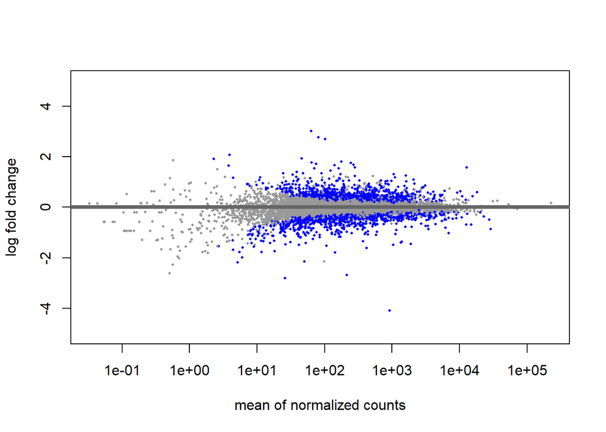

```r
results_30m <- results(dds_30m, name="GAT201_No_vs_Yes")
plotMA(results_30m, ylim=c(-5,5))
```

```r
tresults_30m <- biobroom::tidy.DESeqResults(results_30m)
head(tresults_30m)
```

```
## # A tibble: 6 x 7
##   gene       baseMean estimate stderror statistic p.value p.adjusted
##   <chr>         <dbl>    <dbl>    <dbl>     <dbl>   <dbl>      <dbl>
## 1 CNAG_00002    1702.  0.00991   0.0791     0.125  0.900      0.958
## 2 CNAG_00003     105. -0.230     0.137     -1.68   0.0929     0.242
## 3 CNAG_00004     278. -0.151     0.0968    -1.56   0.119      0.287
## 4 CNAG_00005     523.  0.429     0.185      2.32   0.0205     0.0858
## 5 CNAG_00006     575.  0.177     0.0746     2.37   0.0180     0.0786
## 6 CNAG_00007     640.  0.122     0.0786     1.55   0.121      0.289
```

```r
tresults_30m %>%
dplyr::mutate(minus_log10_pvalue = -log10(p.value)) %>%
readr::write_tsv("~/Documents/GitHub/CryptoGat201RNASeq_draft/results_deseq_2/Gat201_WT_DEseq2_genes30m.txt")

de_Gat201up_30m <- dplyr::filter(tresults_30m, estimate > 0, p.adjusted < 0.05) %>%
              dplyr::arrange(desc(estimate))
de_Gat201up_30m
```

```
## # A tibble: 683 x 7
##    gene       baseMean estimate stderror statistic  p.value p.adjusted
##    <chr>         <dbl>    <dbl>    <dbl>     <dbl>    <dbl>      <dbl>
##  1 CNAG_01560     63.6     3.02    0.588      5.14 2.76e- 7   1.58e- 5
##  2 CNAG_03609     80.6     2.77    0.881      3.15 1.65e- 3   1.35e- 2
##  3 CNAG_04103    102.      2.69    0.307      8.76 1.88e-18   1.16e-15
##  4 CNAG_02729     45.7     1.94    0.709      2.73 6.35e- 3   3.71e- 2
##  5 CNAG_01524    178.      1.80    0.360      5.00 5.61e- 7   2.77e- 5
##  6 CNAG_06659     64.5     1.77    0.213      8.30 1.07e-16   4.85e-14
##  7 CNAG_01571    247.      1.76    0.482      3.65 2.63e- 4   3.39e- 3
##  8 CNAG_00321     75.3     1.71    0.633      2.70 7.00e- 3   4.00e- 2
##  9 CNAG_00588    268.      1.68    0.246      6.83 8.43e-12   1.30e- 9
## 10 CNAG_04104    141.      1.65    0.254      6.52 7.00e-11   8.95e- 9
## # ... with 673 more rows
```

```r
readr::write_tsv(de_Gat201up_30m, "~/Documents/GitHub/CryptoGat201RNASeq_draft/results_deseq_2/Gat201up_DEseq2_padj0p05_30m.txt")
readr::write_lines(de_Gat201up_30m$gene, "~/Documents/GitHub/CryptoGat201RNASeq_draft/results_deseq_2/Gat201up_DEseq2_padj0p05_30m_genesonly.txt")

de_Gat201down_30m <- dplyr::filter(tresults_30m, estimate < 0, p.adjusted < 0.05) %>%
                dplyr::arrange(estimate)
de_Gat201down_30m
```

```
## # A tibble: 594 x 7
##    gene       baseMean estimate stderror statistic  p.value p.adjusted
##    <chr>         <dbl>    <dbl>    <dbl>     <dbl>    <dbl>      <dbl>
##  1 CNAG_01551   928.      -4.09    0.252    -16.2  5.13e-59   3.48e-55
##  2 CNAG_00302    25.9     -2.80    0.262    -10.7  1.19e-26   2.70e-23
##  3 CNAG_06802   215.      -2.69    0.405     -6.64 3.04e-11   4.12e- 9
##  4 CNAG_03658     5.18    -2.18    0.698     -3.12 1.82e- 3   1.45e- 2
##  5 CNAG_03172    50.6     -2.14    0.476     -4.50 6.83e- 6   1.98e- 4
##  6 CNAG_01252     6.00    -2.00    0.455     -4.38 1.16e- 5   2.95e- 4
##  7 CNAG_03461   144.      -1.80    0.175    -10.3  1.17e-24   1.99e-21
##  8 CNAG_05513     5.48    -1.77    0.584     -3.04 2.37e- 3   1.77e- 2
##  9 CNAG_01909    11.7     -1.77    0.532     -3.33 8.82e- 4   8.31e- 3
## 10 CNAG_07896    18.2     -1.74    0.253     -6.87 6.64e-12   1.10e- 9
## # ... with 584 more rows
```

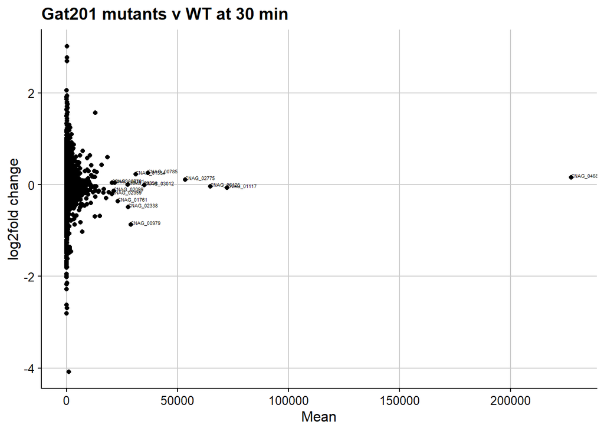

```r
readr::write_tsv(de_Gat201down_30m, "~/Documents/GitHub/CryptoGat201RNASeq_draft/results_deseq_2/Gat201down_DEseq2_padj0p05_30m.txt")
readr::write_lines(de_Gat201down_30m$gene, "~/Documents/GitHub/CryptoGat201RNASeq_draft/results_deseq_2/Gat201down_DEseq2_padj0p05_30m_genesonly.txt")

plot_30m<- qplot(x = baseMean, y = estimate, data = tresults_30m, geom = "point")+
               geom_text(aes(label=ifelse(baseMean> 20000, (gene),'')),hjust=0,vjust=0, cex = 1.5, jitter = 0.5)+
               labs(x ="Mean", y= "log2fold change", title = "Gat201 mutants v WT at 30 min")
plot_30m
```

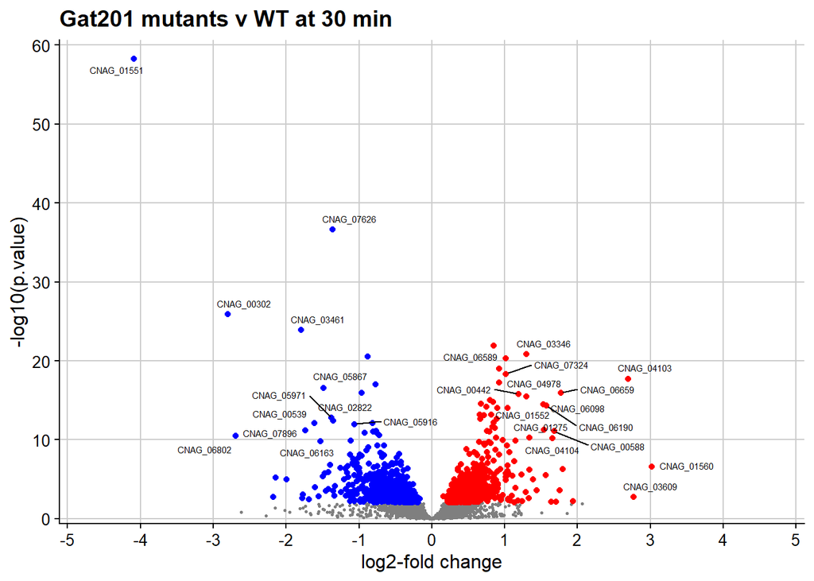

```r
volcano_30m <-
  ggplot(data = tresults_30m, aes(x=estimate,y=-log10(p.value))) +
         geom_point(colour = "grey50",size = 0.5) +
         geom_point(data = de_Gat201up_30m, colour = Gat201up_colour) +
         geom_point(data = de_Gat201down_30m, colour = Gat201down_colour) +
         geom_text_repel(aes(label=ifelse(estimate < -1 & -log10(p.value)> 1.3, (gene),'')), size= 2, max.overlaps = getOption("ggrepel.max.overlaps", default = 15))+
         geom_text_repel(aes(label=ifelse(estimate > 1 & -log10(p.value)> 1.3, (gene),'')), size = 2, max.overlaps = getOption("ggrepel.max.overlaps", default = 15))+
         scale_y_continuous(breaks = c(0,10,20,30,40,50,60),
                            limits = c(0,60),
                            expand = c(0.01,0.01),
                            oob = scales::squish) +
        scale_x_continuous(breaks = seq(-5,5,1),
                            limits = c(-5,5),
                            expand = c(0.01,0.01),
                            oob = scales::squish) +
        labs(x = "log2-fold change",
        title = "Gat201 mutants v WT at 30 min")
volcano_30m
```

```r
ggsave("~/Documents/GitHub/CryptoGat201RNASeq_draft/results_deseq_2/Gat201vWT_30m_volcano.png",
       width = 5,height=5)
```

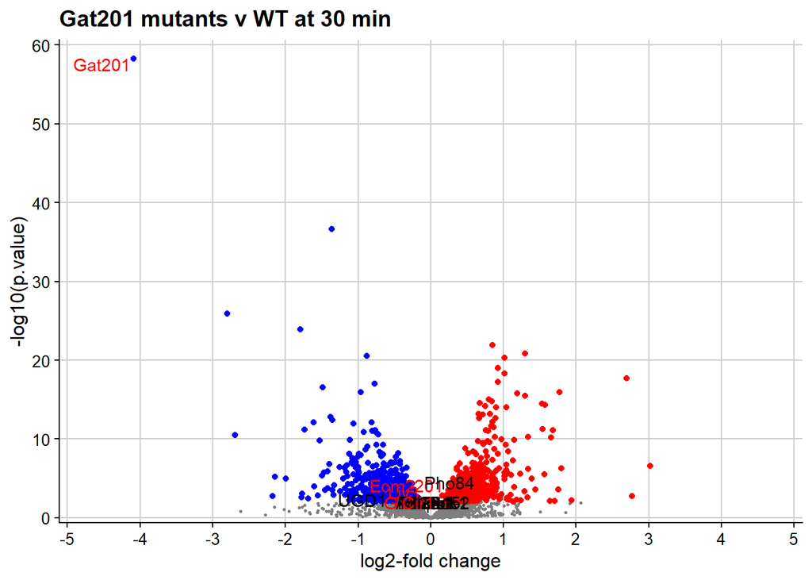

```r
volcano_30msp <-
  ggplot(data = tresults_30m, aes(x=estimate,y=-log10(p.value))) +
         geom_point(colour = "grey50",size = 0.5) +
         geom_point(data = de_Gat201up_30m, colour = Gat201up_colour) +
         geom_point(data = de_Gat201down_30m, colour = Gat201down_colour) +
    geom_text_repel(data = filter(tresults_30m, gene =="CNAG_01551"), label="Gat201",hjust = 1.1,vjust = -0.1, colour= "red")+
    geom_text_repel(data = filter(tresults_30m, gene =="CNAG_06762"), label="Gat204",hjust = 1.1,vjust = -0.1, colour= "red")+
    geom_text_repel(data = filter(tresults_30m, gene =="CNAG_063641"), label="Blp1",hjust = 1.1,vjust = -0.1, colour= "red")+
    geom_text_repel(data = filter(tresults_30m, gene =="CNAG_00883"), label="Ecm2201",hjust = 1.1,vjust = -0.1, colour= "red")+
    geom_text_repel(data = filter(tresults_30m, gene =="CNAG_05835"), label="Liv3",hjust = 1.1,vjust = -0.1, colour= "red")+
    geom_text_repel(data = filter(tresults_30m, gene =="CNAG_03012"), label="CQS1",hjust = 1.1,vjust = -0.1, colour= "red")+
    geom_text_repel(data = filter(tresults_30m, gene =="CNAG_01681"), label="FCY2",hjust = 1.1,vjust = -0.1, colour= "red")+
    geom_text_repel(data = filter(tresults_30m, gene =="CNAG_06401"), label="Ric8",hjust = 1.1,vjust = -0.1, colour= "black")+
    geom_text_repel(data = filter(tresults_30m, gene =="CNAG_07470"), label="Pde2",hjust = 1.1,vjust = -0.1, colour= "black")+
    geom_text_repel(data = filter(tresults_30m, gene =="CNAG_06241"), label="Cfo1",hjust = 1.1,vjust = -0.1, colour= "black")+
    geom_text_repel(data = filter(tresults_30m, gene =="CNAG_02777"), label="Pho84",hjust = 1.1,vjust = -0.1, colour= "black")+
    geom_text_repel(data = filter(tresults_30m, gene =="CNAG_04755"), label="Bck1",hjust = 1.1,vjust = -0.1, colour= "black")+
    geom_text_repel(data = filter(tresults_30m, gene =="CNAG_02357"), label="Mkk2",hjust = 1.1,vjust = -0.1, colour= "black")+
    geom_text_repel(data = filter(tresults_30m, gene =="CNAG_04514"), label="Mpk1",hjust = 1.1,vjust = -0.1, colour= "black")+
    geom_text_repel(data = filter(tresults_30m, gene =="CNAG_04969"), label="UGD1",hjust = 1.1,vjust = -0.1, colour= "black")+
    geom_text_repel(data = filter(tresults_30m, gene =="CNAG_01626"), label="Ada2",hjust = 1.1,vjust = -0.1, colour= "black")+
    geom_text_repel(data = filter(tresults_30m, gene =="CNAG_03024"), label="Rim15",hjust = 1.1,vjust = -0.1, colour= "black")+
    geom_text_repel(data = filter(tresults_30m, gene =="CNAG_04864"), label="Cir1",hjust = 1.1,vjust = -0.1, colour= "red")+
          scale_y_continuous(breaks = c(0,10,20,30,40,50,60),
                            limits = c(0,60),
                            expand = c(0.01,0.01),
                            oob = scales::squish) +
        scale_x_continuous(breaks = seq(-5,5,1),
                            limits = c(-5,5),
                            expand = c(0.01,0.01),
                            oob = scales::squish) +
        labs(x = "log2-fold change",
        title = "Gat201 mutants v WT at 30 min")
volcano_30msp
```

```r
ggsave("~/Documents/GitHub/CryptoGat201RNASeq_draft/results_deseq_2/Gat201vWT_30msp_volcano.png",
       width = 5,height=5)
```

## Gat201 deletion (GAT201 = no) v WT (GAT201 = yes) 2h only

```r
samplesheet_2h <- dplyr::filter(samplesheet, Time == "120")
                  print(samplesheet_2h)
```

```
## # A tibble: 16 x 9
##    SampleID BioRep Media  Timepoint Group    Strain Condition  Time GAT201
##  * <chr>     <dbl> <chr>      <dbl> <chr>    <chr>  <chr>     <dbl> <fct>
##  1 3             1 RPMI         120 A_R_120  A      R           120 Yes
##  2 7             2 RPMI         120 A_R_120  A      R           120 Yes
##  3 10            1 RPMI+S       120 A_RS_120 A      RS          120 Yes
##  4 13            2 RPMI+S       120 A_RS_120 A      RS          120 Yes
##  5 17            1 RPMI         120 a_R_120  a      R           120 Yes
##  6 21            2 RPMI         120 a_R_120  a      R           120 Yes
##  7 24            1 RPMI+S       120 a_RS_120 a      RS          120 Yes
##  8 27            2 RPMI+S       120 a_RS_120 a      RS          120 Yes
##  9 31            1 RPMI         120 B_R_120  B      R           120 No
## 10 35            2 RPMI         120 B_R_120  B      R           120 No
## 11 38            1 RPMI+S       120 B_RS_120 B      RS          120 No
## 12 41            2 RPMI+S       120 B_RS_120 B      RS          120 No
## 13 45            1 RPMI         120 M_R_120  M      R           120 No
## 14 49            2 RPMI         120 M_R_120  M      R           120 No
## 15 52            1 RPMI+S       120 M_RS_120 M      RS          120 No
## 16 55            2 RPMI+S       120 M_RS_120 M      RS          120 No
```

```r
counts_2h <-   dplyr::select(counts, samplesheet_2h$SampleID) %>%
               magrittr::set_rownames(counts$Geneid)

dds_2h <- DESeqDataSetFromMatrix(countData = counts_2h,
                                 colData = samplesheet_2h,
                                 design = ~ GAT201)%>%
        DESeq()

resultsNames(dds_2h)
```

```
## [1] "Intercept"        "GAT201_No_vs_Yes"
```

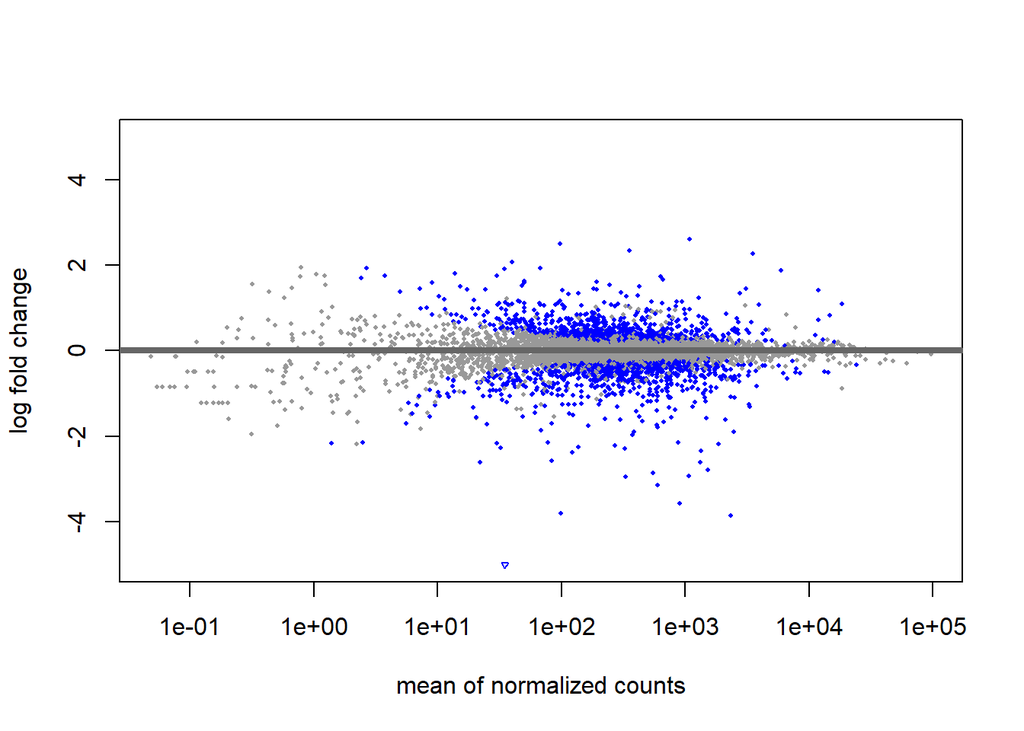

```r
results_2h <- results(dds_2h, name="GAT201_No_vs_Yes")
plotMA(results_2h, ylim=c(-5,5))
```

```r
tresults_2h <- biobroom::tidy.DESeqResults(results_2h)
head(tresults_2h)
```

```
## # A tibble: 6 x 7
##   gene       baseMean estimate stderror statistic     p.value p.adjusted
##   <chr>         <dbl>    <dbl>    <dbl>     <dbl>       <dbl>      <dbl>
## 1 CNAG_00002     508.   0.0533   0.105      0.506 0.613       0.780
## 2 CNAG_00003     135.   0.203    0.131      1.56  0.120       0.297
## 3 CNAG_00004     224.  -0.0699   0.108     -0.649 0.517       0.711
## 4 CNAG_00005     781.   0.742    0.142      5.23  0.000000168 0.00000454
## 5 CNAG_00006    1312.   0.113    0.0712     1.59  0.112       0.284
## 6 CNAG_00007     560.   0.0227   0.102      0.223 0.824       0.908
```

```r
tresults_2h %>%
dplyr::mutate(minus_log10_pvalue = -log10(p.value)) %>%
readr::write_tsv("~/Documents/GitHub/CryptoGat201RNASeq_draft/results_deseq_2/Gat201_WT_DEseq2_genes2h.txt")

de_Gat201up_2h <- dplyr::filter(tresults_2h, estimate > 0, p.adjusted < 0.05) %>%
              dplyr::arrange(desc(estimate))
de_Gat201up_2h
```

```
## # A tibble: 580 x 7
##    gene       baseMean estimate stderror statistic  p.value p.adjusted
##    <chr>         <dbl>    <dbl>    <dbl>     <dbl>    <dbl>      <dbl>
##  1 CNAG_07912  1081.       2.60    0.171     15.2  2.09e-52   1.42e-49
##  2 CNAG_07984    96.9      2.50    0.245     10.2  2.29e-24   3.61e-22
##  3 CNAG_01936   353.       2.34    0.218     10.7  7.23e-27   1.40e-24
##  4 CNAG_00588  3533.       2.27    0.209     10.9  1.42e-27   3.10e-25
##  5 CNAG_01965    40.0      2.07    0.333      6.22 5.08e-10   2.10e- 8
##  6 CNAG_02489    67.8      1.93    0.280      6.88 5.88e-12   3.19e-10
##  7 CNAG_03077     2.68     1.92    0.705      2.73 6.40e- 3   3.87e- 2
##  8 CNAG_01560    34.5      1.90    0.571      3.33 8.68e- 4   8.21e- 3
##  9 CNAG_06347  5905.       1.88    0.431      4.37 1.24e- 5   2.18e- 4
## 10 CNAG_03087    13.7      1.81    0.328      5.51 3.55e- 8   1.05e- 6
## # ... with 570 more rows
```

```r
readr::write_tsv(de_Gat201up_2h, "~/Documents/GitHub/CryptoGat201RNASeq_draft/results_deseq_2/Gat201up_DEseq2_padj0p05_2h.txt")
readr::write_lines(de_Gat201up_2h$gene, "~/Documents/GitHub/CryptoGat201RNASeq_draft/results_deseq_2/Gat201up_DEseq2_padj0p05_2h_genesonly.txt")

de_Gat201down_2h <- dplyr::filter(tresults_2h, estimate < 0, p.adjusted < 0.05) %>%
                dplyr::arrange(estimate)
de_Gat201down_2h
```

```
## # A tibble: 626 x 7
##    gene       baseMean estimate stderror statistic   p.value p.adjusted
##    <chr>         <dbl>    <dbl>    <dbl>     <dbl>     <dbl>      <dbl>
##  1 CNAG_01980     34.8    -5.87    0.524    -11.2  3.95e- 29  9.92e- 27
##  2 CNAG_01551   2342.     -3.86    0.331    -11.6  2.48e- 31  6.46e- 29
##  3 CNAG_06389     98.2    -3.80    0.248    -15.3  3.76e- 53  2.83e- 50
##  4 CNAG_06242    898.     -3.57    0.180    -19.8  2.82e- 87  4.78e- 84
##  5 CNAG_04874    599.     -3.14    0.132    -23.8  5.33e-125  3.61e-121
##  6 CNAG_05916    329.     -2.94    0.133    -22.1  4.58e-108  1.55e-104
##  7 CNAG_00456   1066.     -2.93    0.180    -16.2  3.00e- 59  2.90e- 56
##  8 CNAG_06785    547.     -2.86    0.180    -15.9  4.88e- 57  4.14e- 54
##  9 CNAG_06917   1512.     -2.78    0.202    -13.8  4.33e- 43  2.09e- 40
## 10 CNAG_06802     22.0    -2.62    0.440     -5.94 2.86e-  9  1.06e-  7
## # ... with 616 more rows
```

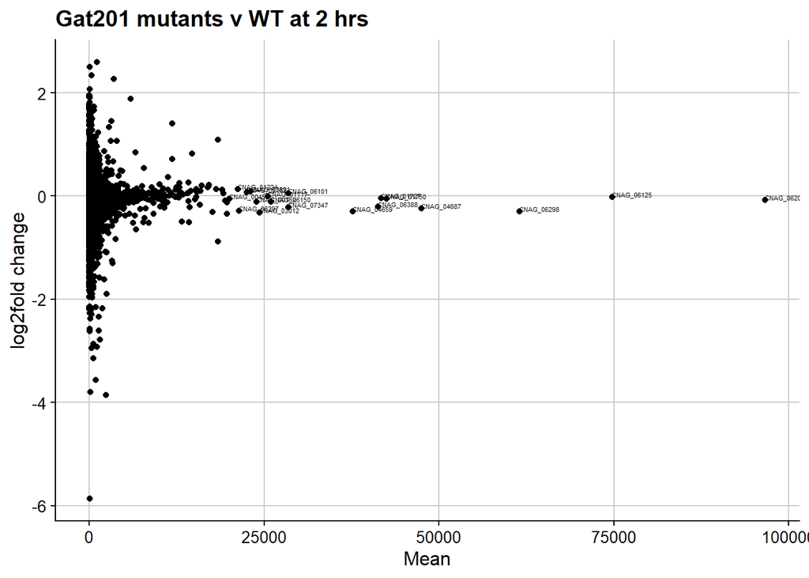

```r
readr::write_tsv(de_Gat201down_2h, "~/Documents/GitHub/CryptoGat201RNASeq_draft/results_deseq_2/Gat201down_DEseq2_padj0p05_2h.txt")
readr::write_lines(de_Gat201down_2h$gene, "~/Documents/GitHub/CryptoGat201RNASeq_draft/results_deseq_2/Gat201down_DEseq2_padj0p05_2h_genesonly.txt")

plot_2h <- qplot(x = baseMean, y = estimate, data = tresults_2h, geom = "point")+
               geom_text(aes(label=ifelse(baseMean> 20000, (gene),'')),hjust=0,vjust=0, cex = 1.5, jitter = 0.5)+
               labs(x ="Mean", y= "log2fold change", title = "Gat201 mutants v WT at 2 hrs")
plot_2h
```

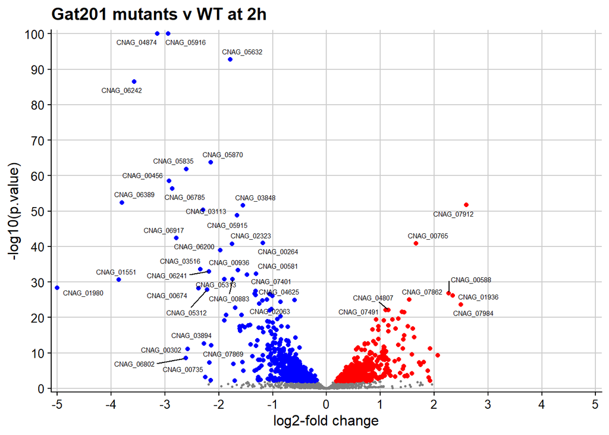

```r
volcano_2h <-
  ggplot(data = tresults_2h, aes(x=estimate,y=-log10(p.value))) +
         geom_point(colour = "grey50",size = 0.5) +
         geom_point(data = de_Gat201up_2h, colour = Gat201up_colour) +
         geom_point(data = de_Gat201down_2h, colour = Gat201down_colour) +
         geom_text_repel(aes(label=ifelse(estimate < -1 & -log10(p.value)> 1.3, (gene),'')), size= 2, max.overlaps = getOption("ggrepel.max.overlaps", default = 15))+
         geom_text_repel(aes(label=ifelse(estimate > 1 & -log10(p.value)> 1.3, (gene),'')), size = 2, max.overlaps = getOption("ggrepel.max.overlaps", default = 15))+
         scale_y_continuous(breaks = c(0,10,20,30,40,50,60,70,80,90,100),
                            limits = c(0,100),
                            expand = c(0.01,0.01),
                            oob = scales::squish) +
        scale_x_continuous(breaks = seq(-5,5,1),
                            limits = c(-5,5),
                            expand = c(0.01,0.01),
                            oob = scales::squish) +
        labs(x = "log2-fold change",
        title = "Gat201 mutants v WT at 2h")
volcano_2h
```

```r
ggsave("~/Documents/GitHub/CryptoGat201RNASeq_draft/results_deseq_2/Gat201vWT_2h_volcano.png",
       width = 5,height=5)
```

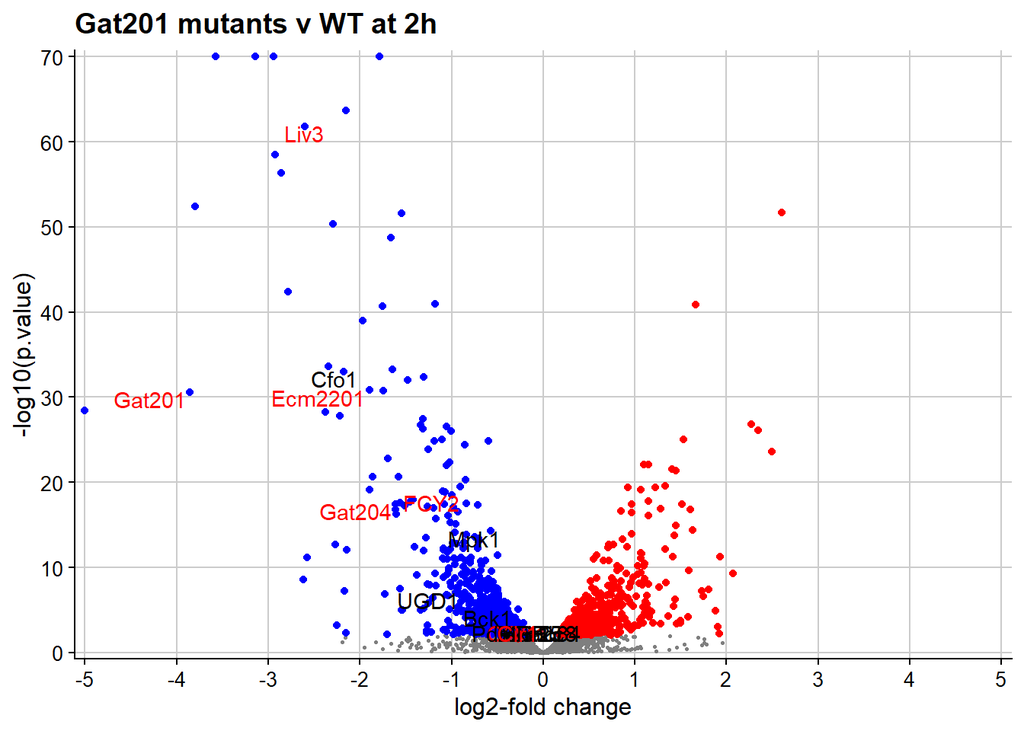

```r
volcano2hsp <-
  ggplot(data = tresults_2h, aes(x=estimate,y=-log10(p.value))) +
         geom_point(colour = "grey50",size = 0.5) +
         geom_point(data = de_Gat201up_2h, colour = Gat201up_colour) +
         geom_point(data = de_Gat201down_2h, colour = Gat201down_colour) +
    geom_text_repel(data = filter(tresults_2h, gene =="CNAG_01551"), label="Gat201",hjust = 1.1,vjust = -0.1, colour= "red")+
    geom_text_repel(data = filter(tresults_2h, gene =="CNAG_06762"), label="Gat204",hjust = 1.1,vjust = -0.1, colour= "red")+
    geom_text_repel(data = filter(tresults_2h, gene =="CNAG_063641"), label="Blp1",hjust = 1.1,vjust = -0.1, colour= "red")+
    geom_text_repel(data = filter(tresults_2h, gene =="CNAG_00883"), label="Ecm2201",hjust = 1.1,vjust = -0.1, colour= "red")+
    geom_text_repel(data = filter(tresults_2h, gene =="CNAG_05835"), label="Liv3",hjust = 1.1,vjust = -0.1, colour= "red")+
    geom_text_repel(data = filter(tresults_2h, gene =="CNAG_03012"), label="CQS1",hjust = 1.1,vjust = -0.1, colour= "red")+
    geom_text_repel(data = filter(tresults_2h, gene =="CNAG_01681"), label="FCY2",hjust = 1.1,vjust = -0.1, colour= "red")+
    geom_text_repel(data = filter(tresults_2h, gene =="CNAG_06401"), label="Ric8",hjust = 1.1,vjust = -0.1, colour= "black")+
    geom_text_repel(data = filter(tresults_2h, gene =="CNAG_07470"), label="Pde2",hjust = 1.1,vjust = -0.1, colour= "black")+
    geom_text_repel(data = filter(tresults_2h, gene =="CNAG_06241"), label="Cfo1",hjust = 1.1,vjust = -0.1, colour= "black")+
    geom_text_repel(data = filter(tresults_2h, gene =="CNAG_02777"), label="Pho84",hjust = 1.1,vjust = -0.1, colour= "black")+
    geom_text_repel(data = filter(tresults_2h, gene =="CNAG_04755"), label="Bck1",hjust = 1.1,vjust = -0.1, colour= "black")+
    geom_text_repel(data = filter(tresults_2h, gene =="CNAG_02357"), label="Mkk2",hjust = 1.1,vjust = -0.1, colour= "black")+
    geom_text_repel(data = filter(tresults_2h, gene =="CNAG_04514"), label="Mpk1",hjust = 1.1,vjust = -0.1, colour= "black")+
    geom_text_repel(data = filter(tresults_2h, gene =="CNAG_04969"), label="UGD1",hjust = 1.1,vjust = -0.1, colour= "black")+
    geom_text_repel(data = filter(tresults_2h, gene =="CNAG_01626"), label="Ada2",hjust = 1.1,vjust = -0.1, colour= "black")+
    geom_text_repel(data = filter(tresults_2h, gene =="CNAG_03024"), label="Rim15",hjust = 1.1,vjust = -0.1, colour= "black")+
    geom_text_repel(data = filter(tresults_2h, gene =="CNAG_04864"), label="Cir1",hjust = 1.1,vjust = -0.1, colour= "red")+
         scale_y_continuous(breaks = c(0,10,20,30,40,50,60,70),
                            limits = c(0,70),
                            expand = c(0.01,0.01),
                            oob = scales::squish) +
        scale_x_continuous(breaks = seq(-5,5,1),
                            limits = c(-5,5),
                            expand = c(0.01,0.01),
                            oob = scales::squish) +
        labs(x = "log2-fold change",
             y = "-log10(p.value)",
             title = "Gat201 mutants v WT at 2h")
volcano2hsp
```

```r
ggsave("~/Documents/GitHub/CryptoGat201RNASeq_draft/results_deseq_2/Gat201vWT_2hsp_volcano.png",
       width = 5,height=5)
```

## Gat201 deletion (GAT201 = no) v WT (GAT201 = yes) 4h only

Filter for 4h time points from samplesheet Select from counts table only counts with ‘x’ Set rownames to make format of table appropriate for DESeq: ‘magrittr::set_rownames’

```r
samplesheet_4h <- dplyr::filter(samplesheet, Time == "240")
                  print(samplesheet_4h)
```

```
## # A tibble: 16 x 9
##    SampleID BioRep Media  Timepoint Group    Strain Condition  Time GAT201
##  * <chr>     <dbl> <chr>      <dbl> <chr>    <chr>  <chr>     <dbl> <fct>
##  1 4             1 RPMI         240 A_R_240  A      R           240 Yes
##  2 8             2 RPMI         240 A_R_240  A      R           240 Yes
##  3 11            1 RPMI+S       240 A_RS_240 A      RS          240 Yes
##  4 14            2 RPMI+S       240 A_RS_240 A      RS          240 Yes
##  5 18            1 RPMI         240 a_R_240  a      R           240 Yes
##  6 22            2 RPMI         240 a_R_240  a      R           240 Yes
##  7 25            1 RPMI+S       240 a_RS_240 a      RS          240 Yes
##  8 28            2 RPMI+S       240 a_RS_240 a      RS          240 Yes
##  9 32            1 RPMI         240 B_R_240  B      R           240 No
## 10 36            2 RPMI         240 B_R_240  B      R           240 No
## 11 39            1 RPMI+S       240 B_RS_240 B      RS          240 No
## 12 42            2 RPMI+S       240 B_RS_240 B      RS          240 No
## 13 46            1 RPMI         240 M_R_240  M      R           240 No
## 14 50            2 RPMI         240 M_R_240  M      R           240 No
## 15 53            1 RPMI+S       240 M_RS_240 M      RS          240 No
## 16 56            2 RPMI+S       240 M_RS_240 M      RS          240 No
```

```r
counts_4h <-   dplyr::select(counts, samplesheet_4h$SampleID) %>%
               magrittr::set_rownames(counts$Geneid)

dds_4h <- DESeqDataSetFromMatrix(countData = counts_4h,
                                 colData = samplesheet_4h,
                                 design = ~ GAT201)%>%
        DESeq()
```

### MA plot 4h

```r
resultsNames(dds_4h)
```

```
## [1] "Intercept"        "GAT201_No_vs_Yes"
```

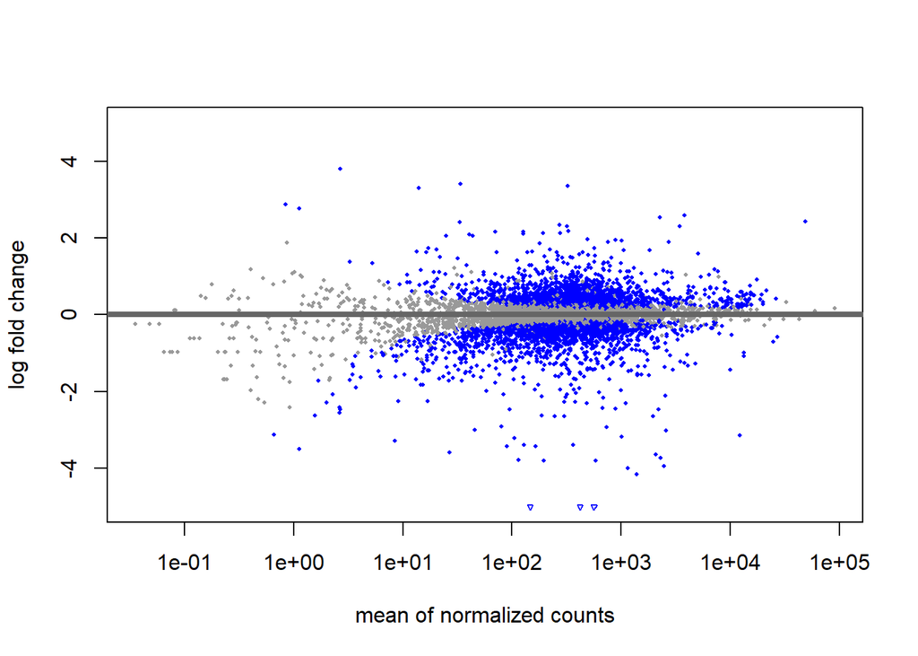

```r
results_4h <- results(dds_4h, name="GAT201_No_vs_Yes")
plotMA(results_4h, ylim=c(-5,5))
```

### Tidy version of results_4h ‘tidy.DESeqResults’ takes big object and just gives the data frame for results_4h

```r
tresults_4h <- biobroom::tidy.DESeqResults(results_4h)
head(tresults_4h)
```

```
## # A tibble: 6 x 7
##   gene       baseMean estimate stderror statistic      p.value  p.adjusted
##   <chr>         <dbl>    <dbl>    <dbl>     <dbl>        <dbl>       <dbl>
## 1 CNAG_00002    302.    0.309    0.109      2.83  0.00467      0.0139
## 2 CNAG_00003     95.2  -0.455    0.128     -3.54  0.000394     0.00173
## 3 CNAG_00004    152.   -0.0890   0.0955    -0.932 0.351        0.477
## 4 CNAG_00005    345.    0.563    0.102      5.51  0.0000000361 0.000000480
## 5 CNAG_00006   1595.    0.309    0.0699     4.42  0.00000999   0.0000719
## 6 CNAG_00007    433.    0.378    0.103      3.67  0.000245     0.00116
```

### Write full output to table for analysis with VolcaNoseR for results_4h

```r
tresults_4h %>%
dplyr::mutate(minus_log10_pvalue = -log10(p.value)) %>%
readr::write_tsv("~/Documents/GitHub/CryptoGat201RNASeq_draft/results_deseq_2/Gat201_WT_DEseq2_genes4h.txt")
```

Select rows with estimated log2fold change >0 and -pvalue <0.05 Arrange in descending row estimate, most DE genes at top New table, similar info to V, just ordered differently, entire table with all stats Took list of genes (de_GAt201up_4h$gene)write to new file. Can use this file GO analysis

```r
de_Gat201up_4h <- dplyr::filter(tresults_4h, estimate > 0, p.adjusted < 0.05) %>%
              dplyr::arrange(desc(estimate))
de_Gat201up_4h
```

```
## # A tibble: 1,489 x 7
##    gene       baseMean estimate stderror statistic  p.value p.adjusted
##    <chr>         <dbl>    <dbl>    <dbl>     <dbl>    <dbl>      <dbl>
##  1 CNAG_07913     2.65     3.79    0.863      4.39 1.12e- 5   8.02e- 5
##  2 CNAG_02984    33.8      3.41    0.290     11.8  5.95e-32   7.32e-30
##  3 CNAG_07912   324.       3.36    0.215     15.6  5.38e-55   1.58e-52
##  4 CNAG_01500    13.9      3.29    0.495      6.65 2.96e-11   6.65e-10
##  5 CNAG_05662  3785.       2.59    0.239     10.9  1.55e-27   1.40e-25
##  6 CNAG_01562  2261.       2.54    0.502      5.06 4.26e- 7   4.52e- 6
##  7 CNAG_06347 49030.       2.42    0.191     12.7  4.38e-37   7.41e-35
##  8 CNAG_05833    33.0      2.41    0.263      9.15 5.67e-20   2.93e-18
##  9 CNAG_00765   274.       2.34    0.167     14.0  2.29e-44   5.52e-42
## 10 CNAG_01272  3424.       2.31    0.197     11.7  9.49e-32   1.11e-29
## # ... with 1,479 more rows
```

```r
readr::write_tsv(de_Gat201up_4h, "~/Documents/GitHub/CryptoGat201RNASeq_draft/results_deseq_2/Gat201up_DEseq2_padj0p05_4h.txt")
readr::write_lines(de_Gat201up_4h$gene, "~/Documents/GitHub/CryptoGat201RNASeq_draft/results_deseq_2/Gat201up_DEseq2_padj0p05_4h_genesonly.txt")
```

### Gat201 deletion (GAT201 = no) v WT (GAT201 = yes) DOWN 4h only

values negative since down regulated

```r
de_Gat201down_4h <- dplyr::filter(tresults_4h, estimate < 0, p.adjusted < 0.05) %>%
                dplyr::arrange(estimate)
de_Gat201down_4h
```

```
## # A tibble: 1,409 x 7
##    gene       baseMean estimate stderror statistic   p.value p.adjusted
##    <chr>         <dbl>    <dbl>    <dbl>     <dbl>     <dbl>      <dbl>
##  1 CNAG_01980     147.    -7.86    0.465    -16.9  4.23e- 64  1.79e- 61
##  2 CNAG_06389     563.    -6.67    0.254    -26.3  4.72e-152  1.59e-148
##  3 CNAG_03894     419.    -6.11    0.360    -17.0  1.50e- 64  6.76e- 62
##  4 CNAG_04874    1391.    -4.17    0.203    -20.5  1.58e- 93  2.67e- 90
##  5 CNAG_06785    1150.    -4.01    0.123    -32.5  4.51e-231  3.05e-227
##  6 CNAG_00456    2472.    -3.94    0.193    -20.4  7.11e- 93  9.61e- 90
##  7 CNAG_06242     584.    -3.81    0.233    -16.3  5.35e- 60  1.81e- 57
##  8 CNAG_05312     196.    -3.80    0.213    -17.9  2.81e- 71  1.59e- 68
##  9 CNAG_00735     114.    -3.78    0.405     -9.33 1.11e- 20  6.15e- 19
## 10 CNAG_01551    2314.    -3.73    0.318    -11.7  7.96e- 32  9.44e- 30
## # ... with 1,399 more rows
```

```r
readr::write_tsv(de_Gat201down_4h, "~/Documents/GitHub/CryptoGat201RNASeq_draft/results_deseq_2/Gat201down_DEseq2_padj0p05_4h.txt")
readr::write_lines(de_Gat201down_4h$gene, "~/Documents/GitHub/CryptoGat201RNASeq_draft/results_deseq_2/Gat201down_DEseq2_padj0p05_4h_genesonly.txt")
```

### Plot log2fold-change (estimate) against baseMean 4h

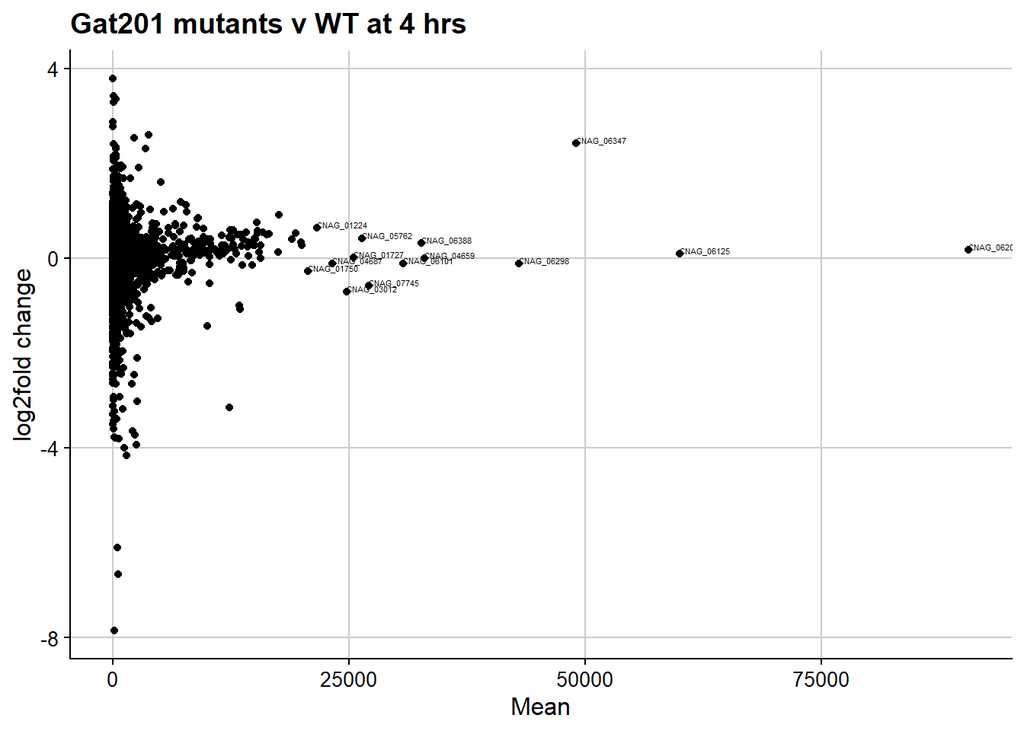

```r
plot_4h<- qplot(x = baseMean, y = estimate, data = tresults_4h, geom = "point")+
               geom_text(aes(label=ifelse(baseMean> 20000, (gene),'')),hjust=0,vjust=0, cex = 1.5, jitter = 0.5)+
               labs(x ="Mean", y= "log2fold change", title = "Gat201 mutants v WT at 4 hrs")
plot_4h
```

### Plot fold-change and p-value (volcano) at 4h

this gives the axis only this lots all genes this plots up genes only inn colour, others in grey this plots down genes (will show up and down in diff colours) change y scale display to show certain p values only to see more out of bounds squish so can still see, will be squished at the top plot between 2e-7 and 2e7

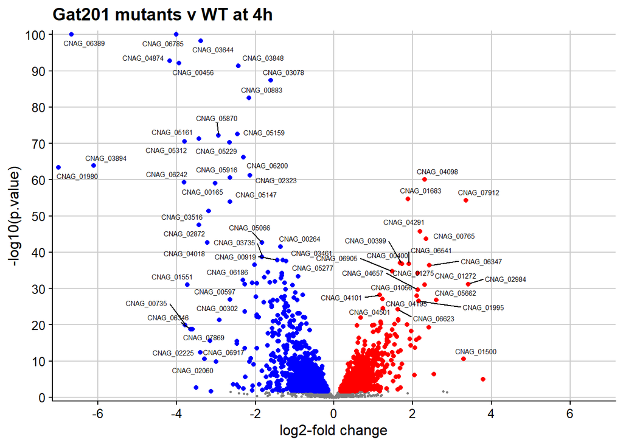

```r
volcano_4h <-
  ggplot(data = tresults_4h, aes(x=estimate,y=-log10(p.value))) +
         geom_point(colour = "grey50",size = 0.5) +
         geom_point(data = de_Gat201up_4h, colour = Gat201up_colour) +
         geom_point(data = de_Gat201down_4h, colour = Gat201down_colour) +
          geom_text_repel(aes(label=ifelse(estimate < -1 & -log10(p.value)> 1.3, (gene),'')), size= 2, max.overlaps = getOption("ggrepel.max.overlaps", default = 15))+
         geom_text_repel(aes(label=ifelse(estimate > 1 & -log10(p.value)> 1.3, (gene),'')), size = 2, max.overlaps = getOption("ggrepel.max.overlaps", default = 15))+
         scale_y_continuous(breaks = c(0,10,20,30,40,50,60,70,80,90,100),
                            limits = c(0,100),
                            expand = c(0.01,0.01),
                            oob = scales::squish) +
        scale_x_continuous(breaks = seq(-6,6,2),
                            limits = c(-7,7),
                            expand = c(0.01,0.01),
                            oob = scales::squish) +
        labs(x = "log2-fold change",
        title = "Gat201 mutants v WT at 4h")
volcano_4h
```

```r
ggsave("~/Documents/GitHub/CryptoGat201RNASeq_draft/results_deseq_2/Gat201vWT_4h.png",
       width = 5,height=5)
```

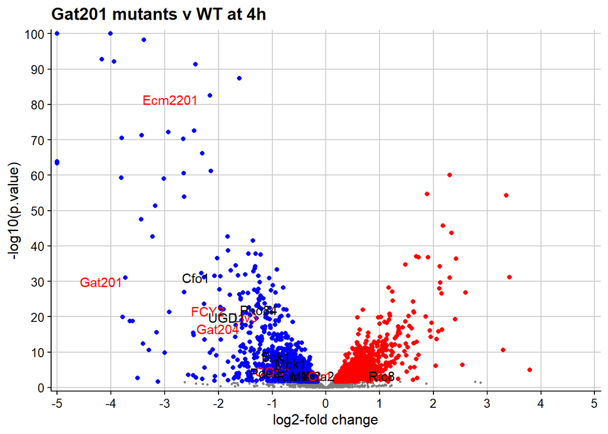

```r
volcano4hsp <-
  ggplot(data = tresults_4h, aes(x=estimate,y=-log10(p.value))) +
         geom_point(colour = "grey50",size = 0.5) +
         geom_point(data = de_Gat201up_4h, colour = Gat201up_colour) +
         geom_point(data = de_Gat201down_4h, colour = Gat201down_colour) +
   geom_text_repel(data = filter(tresults_4h, gene =="CNAG_01551"), label="Gat201",hjust = 1.1,vjust = -0.1, colour= "red")+
    geom_text_repel(data = filter(tresults_4h, gene =="CNAG_06762"), label="Gat204",hjust = 1.1,vjust = -0.1, colour= "red")+
    geom_text_repel(data = filter(tresults_4h, gene =="CNAG_063641"), label="Blp1",hjust = 1.1,vjust = -0.1, colour= "red")+
    geom_text_repel(data = filter(tresults_4h, gene =="CNAG_00883"), label="Ecm2201",hjust = 1.1,vjust = -0.1, colour= "red")+
    geom_text_repel(data = filter(tresults_4h, gene =="CNAG_05835"), label="Liv3",hjust = 1.1,vjust = -0.1, colour= "red")+
    geom_text_repel(data = filter(tresults_4h, gene =="CNAG_03012"), label="CQS1",hjust = 1.1,vjust = -0.1, colour= "red")+
    geom_text_repel(data = filter(tresults_4h, gene =="CNAG_01681"), label="FCY2",hjust = 1.1,vjust = -0.1, colour= "red")+
    geom_text_repel(data = filter(tresults_4h, gene =="CNAG_06401"), label="Ric8",hjust = 1.1,vjust = -0.1, colour= "black")+
    geom_text_repel(data = filter(tresults_4h, gene =="CNAG_07470"), label="Pde2",hjust = 1.1,vjust = -0.1, colour= "black")+
    geom_text_repel(data = filter(tresults_4h, gene =="CNAG_06241"), label="Cfo1",hjust = 1.1,vjust = -0.1, colour= "black")+
    geom_text_repel(data = filter(tresults_4h, gene =="CNAG_02777"), label="Pho84",hjust = 1.1,vjust = -0.1, colour= "black")+
    geom_text_repel(data = filter(tresults_4h, gene =="CNAG_04755"), label="Bck1",hjust = 1.1,vjust = -0.1, colour= "black")+
    geom_text_repel(data = filter(tresults_4h, gene =="CNAG_02357"), label="Mkk2",hjust = 1.1,vjust = -0.1, colour= "black")+
    geom_text_repel(data = filter(tresults_4h, gene =="CNAG_04514"), label="Mpk1",hjust = 1.1,vjust = -0.1, colour= "black")+
    geom_text_repel(data = filter(tresults_4h, gene =="CNAG_04969"), label="UGD1",hjust = 1.1,vjust = -0.1, colour= "black")+
    geom_text_repel(data = filter(tresults_4h, gene =="CNAG_01626"), label="Ada2",hjust = 1.1,vjust = -0.1, colour= "black")+
    geom_text_repel(data = filter(tresults_4h, gene =="CNAG_03024"), label="Rim15",hjust = 1.1,vjust = -0.1, colour= "black")+
    geom_text_repel(data = filter(tresults_4h, gene =="CNAG_04864"), label="Cir1",hjust = 1.1,vjust = -0.1, colour= "red")+
         scale_y_continuous(breaks = c(0,10,20,30,40,50,60,70,80,90,100),
                            limits = c(0,100),
                            expand = c(0.01,0.01),
                            oob = scales::squish) +
        scale_x_continuous(breaks = seq(-5,5,1),
                            limits = c(-5,5),
                            expand = c(0.01,0.01),
                            oob = scales::squish) +
        labs(x = "log2-fold change",
             y = "-log10(p.value)",
             title = "Gat201 mutants v WT at 4h")
volcano4hsp
```

```r
ggsave("~/Documents/GitHub/CryptoGat201RNASeq_draft/results_deseq_2/Gat201vWT_4hsp.png",
       width = 5,height=5)
```

```r
samplesheet_0_30 <- samplesheet %>% filter(Time == "0" | Time == "30") %>%
                    filter(GAT201 == "Yes")
                    print(samplesheet_0_30)
```

```
## # A tibble: 12 x 9
##    SampleID BioRep Media  Timepoint Group   Strain Condition  Time GAT201
##  * <chr>     <dbl> <chr>      <dbl> <chr>   <chr>  <chr>     <dbl> <fct>
##  1 1             1 YPD            0 A_Y_0   A      Y             0 Yes
##  2 2             1 RPMI          30 A_R_30  A      R            30 Yes
##  3 5b            2 YPD            0 A_Y_0   A      Y             0 Yes
##  4 6             2 RPMI          30 A_R_30  A      R            30 Yes
##  5 9             1 RPMI+S        30 A_RS_30 A      RS           30 Yes
##  6 12            2 RPMI+S        30 A_RS_30 A      RS           30 Yes
##  7 15            1 YPD            0 a_Y_0   a      Y             0 Yes
##  8 16            1 RPMI          30 a_R_30  a      R            30 Yes
##  9 19            2 YPD            0 a_Y_0   a      Y             0 Yes
## 10 20            2 RPMI          30 a_R_30  a      R            30 Yes
## 11 23            1 RPMI+S        30 a_RS_30 a      RS           30 Yes
## 12 26            2 RPMI+S        30 a_RS_30 a      RS           30 Yes
```

```r
counts_0_30 <-   dplyr::select(counts, samplesheet_0_30$SampleID) %>%
                 magrittr::set_rownames(counts$Geneid)

dds_0_30 <- DESeqDataSetFromMatrix(countData = counts_0_30,
                                 colData = samplesheet_0_30,
                                 design = ~ Time)%>%
        DESeq()

resultsNames(dds_0_30)
```

```
## [1] "Intercept" "Time"
```

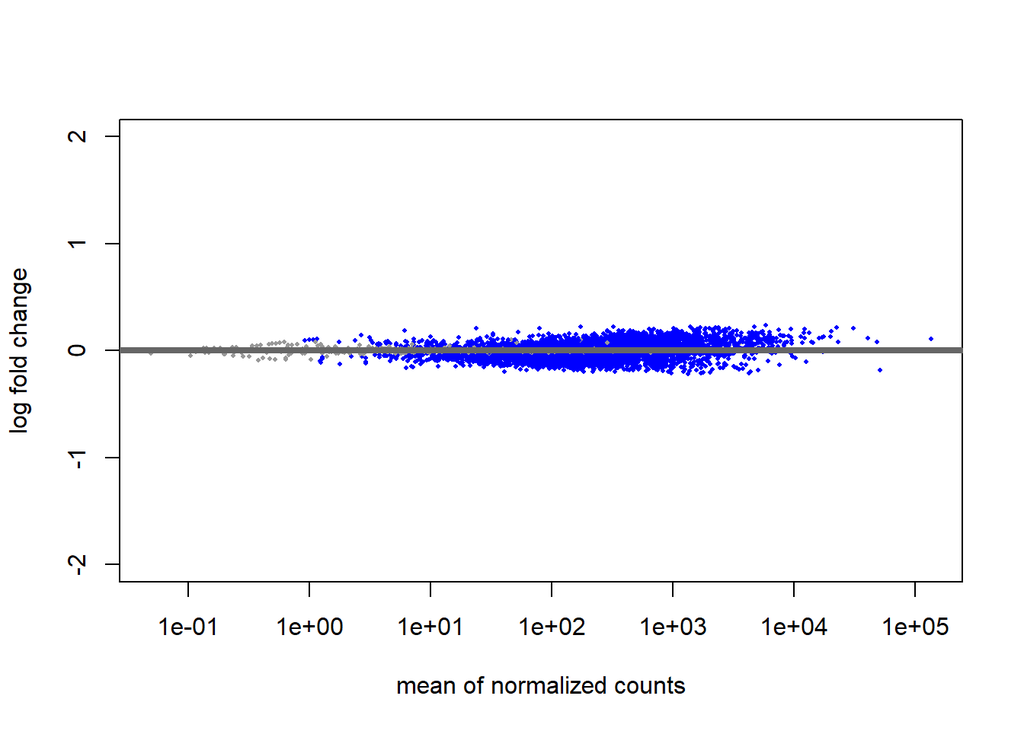

```r
results_0_30 <- results(dds_0_30, name="Time")
plotMA(results_0_30, ylim=c(-2,2))
```

```r
tresults_0_30 <- biobroom::tidy.DESeqResults(results_0_30)
head(tresults_0_30)
```

```
## # A tibble: 6 x 7
##   gene       baseMean estimate stderror statistic   p.value p.adjusted
##   <chr>         <dbl>    <dbl>    <dbl>     <dbl>     <dbl>      <dbl>
## 1 CNAG_00002    1106.  0.0836   0.00385     21.7  1.50e-104  1.64e-103
## 2 CNAG_00003     139. -0.0352   0.00507     -6.94 4.03e- 12  7.92e- 12
## 3 CNAG_00004     256.  0.00367  0.00332      1.10 2.70e-  1  3.02e-  1
## 4 CNAG_00005     384.  0.00629  0.00536      1.17 2.40e-  1  2.71e-  1
## 5 CNAG_00006     614. -0.0283   0.00421     -6.71 1.93e- 11  3.71e- 11
## 6 CNAG_00007     401.  0.0831   0.00437     19.0  1.75e- 80  1.34e- 79
```

```r
tresults_0_30 %>%
dplyr::mutate(minus_log10_pvalue = -log10(p.value)) %>%
readr::write_tsv("~/Documents/GitHub/CryptoGat201RNASeq_draft/results_deseq_2/0v30Gat201mut.txt")

de_Gat201up_0_30 <- dplyr::filter(tresults_0_30, estimate > 0, p.adjusted < 0.05) %>%
              dplyr::arrange(desc(estimate))
de_Gat201up_0_30
```

```
## # A tibble: 2,774 x 7
##    gene       baseMean estimate stderror statistic   p.value p.adjusted
##    <chr>         <dbl>    <dbl>    <dbl>     <dbl>     <dbl>      <dbl>
##  1 CNAG_05144    5900.    0.234  0.00591      39.6 0          0
##  2 CNAG_04298    1401.    0.226  0.00649      34.8 1.53e-265  1.24e-263
##  3 CNAG_05425    4702.    0.224  0.00533      42.0 0          0
##  4 CNAG_01810     324.    0.224  0.0115       19.5 1.31e- 84  1.06e- 83
##  5 CNAG_00934     173.    0.223  0.0153       14.6 5.16e- 48  2.26e- 47
##  6 CNAG_00979   22489.    0.216  0.00762      28.3 2.34e-176  6.29e-175
##  7 CNAG_04694    1695.    0.214  0.00612      34.9 1.37e-267  1.15e-265
##  8 CNAG_01877    2403.    0.214  0.00532      40.2 0          0
##  9 CNAG_04347    2259.    0.212  0.00515      41.2 0          0
## 10 CNAG_06517    1012.    0.212  0.00720      29.4 8.56e-190  2.68e-188
## # ... with 2,764 more rows
```

```r
readr::write_tsv(de_Gat201up_0_30, "~/Documents/GitHub/CryptoGat201RNASeq_draft/results_deseq_2/0v30Gat201mutup_padj0p05.txt")
readr::write_lines(de_Gat201up_0_30$gene, "~/Documents/GitHub/CryptoGat201RNASeq_draft/results_deseq_2/0v30Gat201mutup_padj0p05_genesonly.txt")

de_Gat201down_0_30 <- dplyr::filter(tresults_0_30, estimate < 0, p.adjusted < 0.05) %>%
                dplyr::arrange(estimate)
de_Gat201down_0_30
```

```
## # A tibble: 2,800 x 7
##    gene       baseMean estimate stderror statistic   p.value p.adjusted
##    <chr>         <dbl>    <dbl>    <dbl>     <dbl>     <dbl>      <dbl>
##  1 CNAG_06169   1343.    -0.216  0.00567     -38.1 0          0
##  2 CNAG_00091   1714.    -0.212  0.00395     -53.5 0          0
##  3 CNAG_06453   4252.    -0.209  0.00509     -41.0 0          0
##  4 CNAG_06074    969.    -0.208  0.00553     -37.6 0          0
##  5 CNAG_01102   1785.    -0.208  0.00395     -52.6 0          0
##  6 CNAG_01534   2037.    -0.203  0.00613     -33.2 2.59e-241  1.50e-239
##  7 CNAG_06064     40.7   -0.201  0.0156      -12.9 4.33e- 38  1.56e- 37
##  8 CNAG_00834    185.    -0.198  0.00686     -28.9 1.61e-183  4.74e-182
##  9 CNAG_04903    919.    -0.197  0.00539     -36.6 1.30e-292  1.44e-290
## 10 CNAG_01052    219.    -0.197  0.00664     -29.6 5.24e-193  1.70e-191
## # ... with 2,790 more rows
```

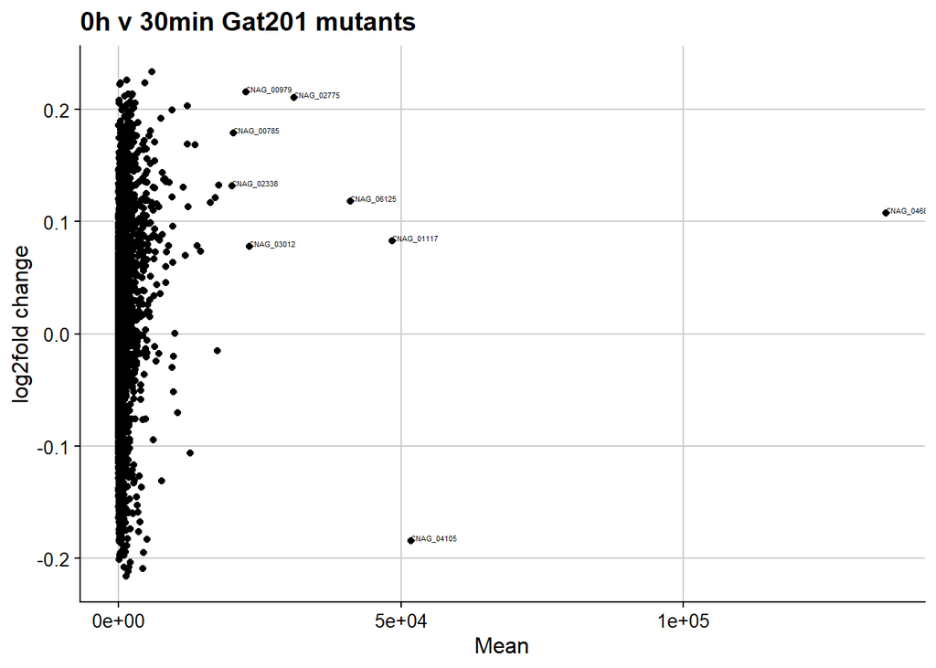

```r
readr::write_tsv(de_Gat201down_0_30, "~/Documents/GitHub/CryptoGat201RNASeq_draft/results_deseq_2/0v30Gat201mutdown_padj0p05.txt")
readr::write_lines(de_Gat201down_0_30$gene, "~/Documents/GitHub/CryptoGat201RNASeq_draft/results_deseq_2/0v30Gat201mutdown_padj0p05h_genesonly.txt")

plot_0_30<- qplot(x = baseMean, y = estimate, data = tresults_0_30, geom = "point")+
               geom_text(aes(label=ifelse(baseMean> 20000, (gene),'')),hjust=0,vjust=0, cex = 1.5, jitter = 0.5)+
               labs(x ="Mean", y= "log2fold change", title = "0h v 30min Gat201 mutants")
plot_0_30
```

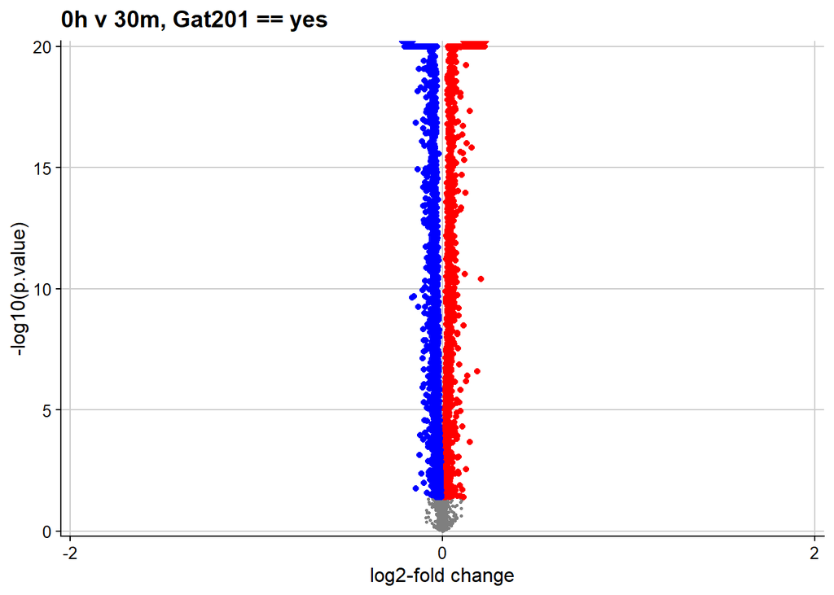

```r
volcano_0_30 <-
  ggplot(data = tresults_0_30, aes(x=estimate,y=-log10(p.value))) +
         geom_point(colour = "grey50",size = 0.5) +
         geom_point(data = de_Gat201up_0_30, colour = Gat201up_colour) +
         geom_point(data = de_Gat201down_0_30, colour = Gat201down_colour) +
         geom_text_repel(aes(label=ifelse(estimate < -1 & -log10(p.value)> 1.3, (gene),'')), size= 2, max.overlaps = getOption("ggrepel.max.overlaps", default = 15))+
         geom_text_repel(aes(label=ifelse(estimate > 1 & -log10(p.value)> 1.3, (gene),'')), size = 2, max.overlaps = getOption("ggrepel.max.overlaps", default = 15))+
         scale_y_continuous(breaks = c(0,5,10,15,20),
                            limits = c(0,20),
                            expand = c(0.01,0.01),
                            oob = scales::squish) +
        scale_x_continuous(breaks = seq(-2,2,2),
                            limits = c(-2,2),
                            expand = c(0.01,0.01),
                            oob = scales::squish) +
        labs(x = "log2-fold change",
        title = "0h v 30m, Gat201 == yes")
volcano_0_30
```

```r
ggsave("~/Documents/GitHub/CryptoGat201RNASeq_draft/results_deseq_2/0v30Gat201.png",
       width = 5,height=5)
```

## 0h v 2h, Gat201 mutants

```r
samplesheet0_2 <- samplesheet %>% filter(Time == "0" | Time == "120") %>%
                    filter(GAT201 == "Yes")
                    print(samplesheet0_2)
```

```
## # A tibble: 12 x 9
##    SampleID BioRep Media  Timepoint Group    Strain Condition  Time GAT201
##  * <chr>     <dbl> <chr>      <dbl> <chr>    <chr>  <chr>     <dbl> <fct>
##  1 1             1 YPD            0 A_Y_0    A      Y             0 Yes
##  2 3             1 RPMI         120 A_R_120  A      R           120 Yes
##  3 5b            2 YPD            0 A_Y_0    A      Y             0 Yes
##  4 7             2 RPMI         120 A_R_120  A      R           120 Yes
##  5 10            1 RPMI+S       120 A_RS_120 A      RS          120 Yes
##  6 13            2 RPMI+S       120 A_RS_120 A      RS          120 Yes
##  7 15            1 YPD            0 a_Y_0    a      Y             0 Yes
##  8 17            1 RPMI         120 a_R_120  a      R           120 Yes
##  9 19            2 YPD            0 a_Y_0    a      Y             0 Yes
## 10 21            2 RPMI         120 a_R_120  a      R           120 Yes
## 11 24            1 RPMI+S       120 a_RS_120 a      RS          120 Yes
## 12 27            2 RPMI+S       120 a_RS_120 a      RS          120 Yes
```

```r
counts0_2 <-   dplyr::select(counts, samplesheet0_2$SampleID) %>%
                 magrittr::set_rownames(counts$Geneid)

dds_0_2 <- DESeqDataSetFromMatrix(countData = counts0_2,
                                 colData = samplesheet0_2,
                                 design = ~ Time)%>%
        DESeq()

resultsNames(dds_0_2)
```

```
## [1] "Intercept" "Time"
```

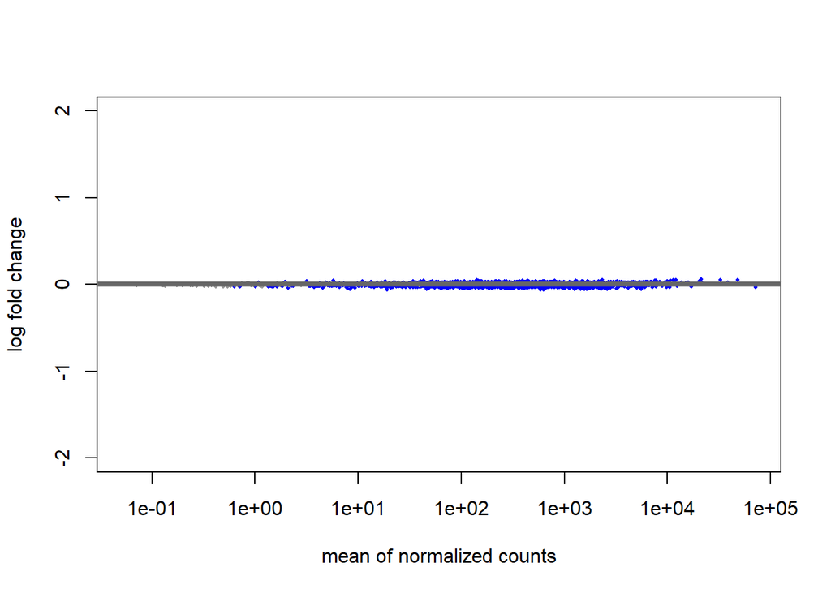

```r
results_0_2 <- results(dds_0_2, name="Time")
plotMA(results_0_2, ylim=c(-2,2))
```

```r
tresults_0_2 <- biobroom::tidy.DESeqResults(results_0_2)
head(tresults_0_2)
```

```
## # A tibble: 6 x 7
##   gene       baseMean  estimate stderror statistic  p.value p.adjusted
##   <chr>         <dbl>     <dbl>    <dbl>     <dbl>    <dbl>      <dbl>
## 1 CNAG_00002     355.  0.000438  0.00100     0.436 6.63e- 1   6.97e- 1
## 2 CNAG_00003     152. -0.0133    0.00135    -9.89  4.47e-23   1.68e-22
## 3 CNAG_00004     215. -0.00773   0.00117    -6.61  3.88e-11   8.93e-11
## 4 CNAG_00005     432. -0.000932  0.00139    -0.670 5.03e- 1   5.43e- 1
## 5 CNAG_00006     980. -0.00262   0.00103    -2.54  1.11e- 2   1.50e- 2
## 6 CNAG_00007     310.  0.0138    0.00123    11.2   3.38e-29   1.56e-28
```

```r
tresults_0_2 %>%
dplyr::mutate(minus_log10_pvalue = -log10(p.value)) %>%
readr::write_tsv("~/Documents/GitHub/CryptoGat201RNASeq_draft/results_deseq_2/0v2Gat201mut.txt")

de_Gat201up_0_2 <- dplyr::filter(tresults_0_2, estimate > 0, p.adjusted < 0.05) %>%
              dplyr::arrange(desc(estimate))
de_Gat201up_0_2
```

```
## # A tibble: 2,658 x 7
##    gene       baseMean estimate stderror statistic   p.value p.adjusted
##    <chr>         <dbl>    <dbl>    <dbl>     <dbl>     <dbl>      <dbl>
##  1 CNAG_06388  21353.    0.0588  0.00242     24.3  5.43e-130  2.36e-128
##  2 CNAG_06298  32766.    0.0548  0.00208     26.4  8.68e-154  6.00e-152
##  3 CNAG_06207  48125.    0.0510  0.00204     25.0  6.06e-138  3.11e-136
##  4 CNAG_00162  12037.    0.0507  0.00195     26.0  1.80e-149  1.15e-147
##  5 CNAG_06297  11421.    0.0495  0.00215     23.0  4.63e-117  1.55e-115
##  6 CNAG_02235    141.    0.0490  0.00366     13.4  6.63e- 41  4.40e- 40
##  7 CNAG_00895   2335.    0.0489  0.00489      9.99 1.64e- 23  6.24e- 23
##  8 CNAG_06242    803.    0.0469  0.00173     27.2  2.28e-162  1.82e-160
##  9 CNAG_04756    394.    0.0463  0.00246     18.8  9.36e- 79  1.52e- 77
## 10 CNAG_05813     42.9   0.0453  0.00556      8.15 3.74e- 16  1.09e- 15
## # ... with 2,648 more rows
```

```r
readr::write_tsv(de_Gat201up_0_2, "~/Documents/GitHub/CryptoGat201RNASeq_draft/results_deseq_2/0v2Gat201mutup_padj0p05.txt")
readr::write_lines(de_Gat201up_0_2$gene, "~/Documents/GitHub/CryptoGat201RNASeq_draft/results_deseq_2/0v2Gat201mutup_padj0p05_genesonly.txt")

de_Gat201down_0_2 <- dplyr::filter(tresults_0_2, estimate < 0, p.adjusted < 0.05) %>%
                dplyr::arrange(estimate)
de_Gat201down_0_2
```

```
## # A tibble: 2,698 x 7
##    gene       baseMean estimate stderror statistic   p.value p.adjusted
##    <chr>         <dbl>    <dbl>    <dbl>     <dbl>     <dbl>      <dbl>
##  1 CNAG_04459   632.    -0.0606  0.00162    -37.5  0          0
##  2 CNAG_01827    19.1   -0.0588  0.00614     -9.58 9.70e- 22  3.47e- 21
##  3 CNAG_07308   590.    -0.0587  0.00249    -23.6  8.28e-123  3.17e-121
##  4 CNAG_03782  1434.    -0.0563  0.00204    -27.6  1.17e-167  1.00e-165
##  5 CNAG_01534  2606.    -0.0556  0.00137    -40.6  0          0
##  6 CNAG_01919  5560.    -0.0550  0.00132    -41.8  0          0
##  7 CNAG_07790     8.36  -0.0549  0.00810     -6.78 1.23e- 11  2.88e- 11
##  8 CNAG_03666  1251.    -0.0539  0.00153    -35.2  3.92e-272  1.90e-269
##  9 CNAG_02899  1572.    -0.0534  0.00215    -24.8  5.63e-136  2.75e-134
## 10 CNAG_02118  2263.    -0.0530  0.00146    -36.3  6.22e-288  3.83e-285
## # ... with 2,688 more rows
```

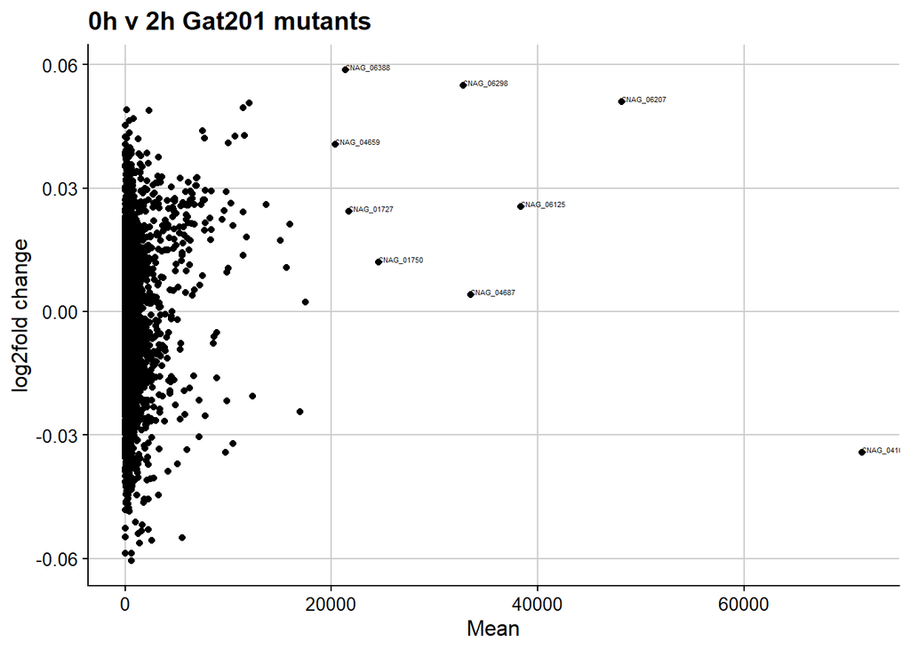

```r
readr::write_tsv(de_Gat201down_0_2, "~/Documents/GitHub/CryptoGat201RNASeq_draft/results_deseq_2/0v2Gat201mutdown_padj0p05.txt")
readr::write_lines(de_Gat201down_0_2$gene, "~/Documents/GitHub/CryptoGat201RNASeq_draft/results_deseq_2/0v2Gat201mutdown_padj0p05h_genesonly.txt")

plot_0_2<- qplot(x = baseMean, y = estimate, data = tresults_0_2, geom = "point")+
               geom_text(aes(label=ifelse(baseMean> 20000, (gene),'')),hjust=0,vjust=0, cex = 1.5, jitter = 0.5)+
               labs(x ="Mean", y= "log2fold change", title = "0h v 2h Gat201 mutants")
plot_0_2
```

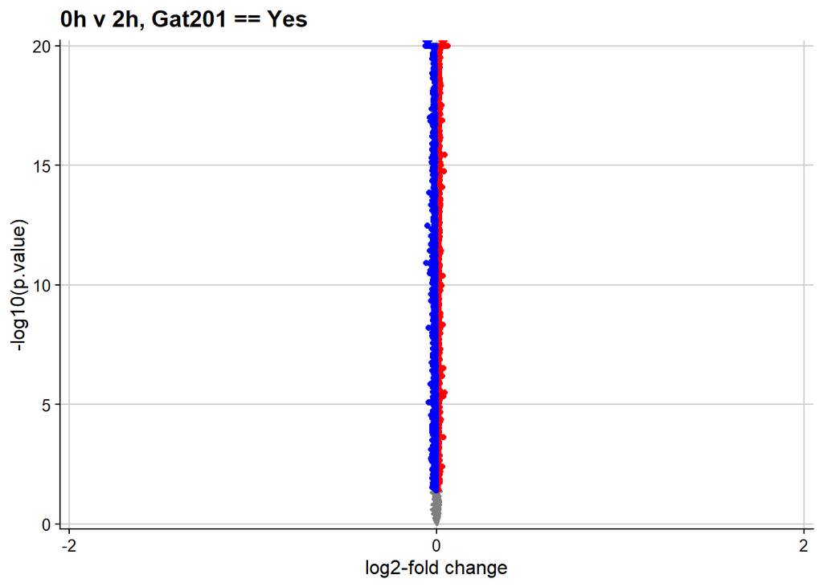

```r
volcano_0_2 <-
  ggplot(data = tresults_0_2, aes(x=estimate,y=-log10(p.value))) +
         geom_point(colour = "grey50",size = 0.5) +
         geom_point(data = de_Gat201up_0_2, colour = Gat201up_colour) +
         geom_point(data = de_Gat201down_0_2, colour = Gat201down_colour) +
         geom_text_repel(aes(label=ifelse(estimate < -1 & -log10(p.value)> 1.3, (gene),'')), size= 2, max.overlaps = getOption("ggrepel.max.overlaps", default = 15))+
         geom_text_repel(aes(label=ifelse(estimate > 1 & -log10(p.value)> 1.3, (gene),'')), size = 2, max.overlaps = getOption("ggrepel.max.overlaps", default = 15))+
         scale_y_continuous(breaks = c(0,5,10,15,20),
                            limits = c(0,20),
                            expand = c(0.01,0.01),
                            oob = scales::squish) +
        scale_x_continuous(breaks = seq(-2,2,2),
                            limits = c(-2,2),
                            expand = c(0.01,0.01),
                            oob = scales::squish) +
        labs(x = "log2-fold change",
        title = "0h v 2h, Gat201 == Yes")
volcano_0_2
```

```r
ggsave("~/Documents/GitHub/CryptoGat201RNASeq_draft/results_deseq_2/0v2Gat201.png",
       width = 5,height=5)
```

## 0h v 4h, Gat201 mutants

```r
samplesheet0_4 <- samplesheet %>% filter(Time == "0" | Time == "240") %>%
                    filter(GAT201 == "Yes")
                    print(samplesheet0_4)
```

```
## # A tibble: 12 x 9
##    SampleID BioRep Media  Timepoint Group    Strain Condition  Time GAT201
##  * <chr>     <dbl> <chr>      <dbl> <chr>    <chr>  <chr>     <dbl> <fct>
##  1 1             1 YPD            0 A_Y_0    A      Y             0 Yes
##  2 4             1 RPMI         240 A_R_240  A      R           240 Yes
##  3 5b            2 YPD            0 A_Y_0    A      Y             0 Yes
##  4 8             2 RPMI         240 A_R_240  A      R           240 Yes
##  5 11            1 RPMI+S       240 A_RS_240 A      RS          240 Yes
##  6 14            2 RPMI+S       240 A_RS_240 A      RS          240 Yes
##  7 15            1 YPD            0 a_Y_0    a      Y             0 Yes
##  8 18            1 RPMI         240 a_R_240  a      R           240 Yes
##  9 19            2 YPD            0 a_Y_0    a      Y             0 Yes
## 10 22            2 RPMI         240 a_R_240  a      R           240 Yes
## 11 25            1 RPMI+S       240 a_RS_240 a      RS          240 Yes
## 12 28            2 RPMI+S       240 a_RS_240 a      RS          240 Yes
```

```r
counts0_4 <-   dplyr::select(counts, samplesheet0_4$SampleID) %>%
                 magrittr::set_rownames(counts$Geneid)

dds_0_4 <- DESeqDataSetFromMatrix(countData = counts0_4,
                                 colData = samplesheet0_4,
                                 design = ~ Time)%>%
        DESeq()

resultsNames(dds_0_4)
```

```
## [1] "Intercept" "Time"
```

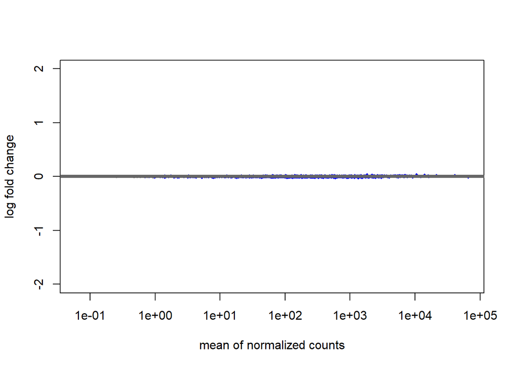

```r
results_0_4 <- results(dds_0_4, name="Time")
plotMA(results_0_4, ylim=c(-2,2))
```

```r
tresults_0_4 <- biobroom::tidy.DESeqResults(results_0_4)
head(tresults_0_4)
```

```
## # A tibble: 6 x 7
##   gene       baseMean  estimate stderror statistic  p.value p.adjusted
##   <chr>         <dbl>     <dbl>    <dbl>     <dbl>    <dbl>      <dbl>
## 1 CNAG_00002     237. -0.00319  0.000521    -6.11  9.71e-10   2.14e- 9
## 2 CNAG_00003     139. -0.00716  0.000726    -9.87  5.89e-23   2.44e-22
## 3 CNAG_00004     173. -0.00586  0.000544   -10.8   4.83e-27   2.35e-26
## 4 CNAG_00005     275. -0.00464  0.000693    -6.69  2.23e-11   5.38e-11
## 5 CNAG_00006    1033. -0.000283 0.000537    -0.527 5.98e- 1   6.34e- 1
## 6 CNAG_00007     220.  0.00486  0.000616     7.89  3.01e-15   8.92e-15
```

```r
tresults_0_4 %>%
dplyr::mutate(minus_log10_pvalue = -log10(p.value)) %>%
readr::write_tsv("~/Documents/GitHub/CryptoGat201RNASeq_draft/results_deseq_2/0v4Gat201mut.txt")

de_Gat201up_0_4 <- dplyr::filter(tresults_0_4, estimate > 0, p.adjusted < 0.05) %>%
                   dplyr::arrange(desc(estimate))
de_Gat201up_0_4
```

```
## # A tibble: 2,636 x 7
##    gene       baseMean estimate stderror statistic   p.value p.adjusted
##    <chr>         <dbl>    <dbl>    <dbl>     <dbl>     <dbl>      <dbl>
##  1 CNAG_06346   1830.    0.0376 0.00163      23.0  4.78e-117  2.38e-115
##  2 CNAG_06917  10561.    0.0342 0.000670     51.1  0          0
##  3 CNAG_00165   2193.    0.0318 0.00129      24.7  1.23e-134  9.47e-133
##  4 CNAG_06388  13965.    0.0272 0.00105      25.9  2.34e-147  2.48e-145
##  5 CNAG_06389    532.    0.0269 0.00202      13.3  1.32e- 40  1.04e- 39
##  6 CNAG_01980    140.    0.0269 0.00243      11.1  1.51e- 28  7.84e- 28
##  7 CNAG_04756    569.    0.0257 0.00137      18.8  1.03e- 78  2.40e- 77
##  8 CNAG_05813     63.6   0.0253 0.00281       9.03 1.75e- 19  6.27e- 19
##  9 CNAG_06298  21542.    0.0252 0.000978     25.8  7.30e-147  7.49e-145
## 10 CNAG_04215   1470.    0.0250 0.000896     27.9  7.10e-171  1.37e-168
## # ... with 2,626 more rows
```

```r
readr::write_tsv(de_Gat201up_0_4, "~/Documents/GitHub/CryptoGat201RNASeq_draft/results_deseq_2/0v4Gat201mutup_padj0p05.txt")
readr::write_lines(de_Gat201up_0_4$gene, "~/Documents/GitHub/CryptoGat201RNASeq_draft/results_deseq_2/0v4Gat201mutup_padj0p05_genesonly.txt")

de_Gat201down_0_4 <- dplyr::filter(tresults_0_4, estimate < 0, p.adjusted < 0.05) %>%
                     dplyr::arrange(estimate)
de_Gat201down_0_4
```

```
## # A tibble: 2,713 x 7
##    gene       baseMean estimate stderror statistic   p.value p.adjusted
##    <chr>         <dbl>    <dbl>    <dbl>     <dbl>     <dbl>      <dbl>
##  1 CNAG_04459   597.    -0.0312 0.000923    -33.8  9.80e-250  8.29e-247
##  2 CNAG_03782  1348.    -0.0304 0.000860    -35.4  2.80e-274  6.31e-271
##  3 CNAG_06172    43.1   -0.0292 0.00221     -13.2  6.94e- 40  5.34e- 39
##  4 CNAG_03666  1177.    -0.0288 0.00180     -16.0  1.87e- 57  2.42e- 56
##  5 CNAG_00490   934.    -0.0286 0.00173     -16.6  1.60e- 61  2.31e- 60
##  6 CNAG_07790     7.86  -0.0284 0.00690      -4.12 3.82e-  5  6.31e-  5
##  7 CNAG_01534  2467.    -0.0276 0.000911    -30.3  2.70e-202  1.02e-199
##  8 CNAG_01827    18.2   -0.0275 0.00289      -9.53 1.60e- 21  6.23e- 21
##  9 CNAG_02045   110.    -0.0272 0.00132     -20.7  4.64e- 95  1.45e- 93
## 10 CNAG_02899  1486.    -0.0268 0.00111     -24.2  5.69e-129  3.60e-127
## # ... with 2,703 more rows
```

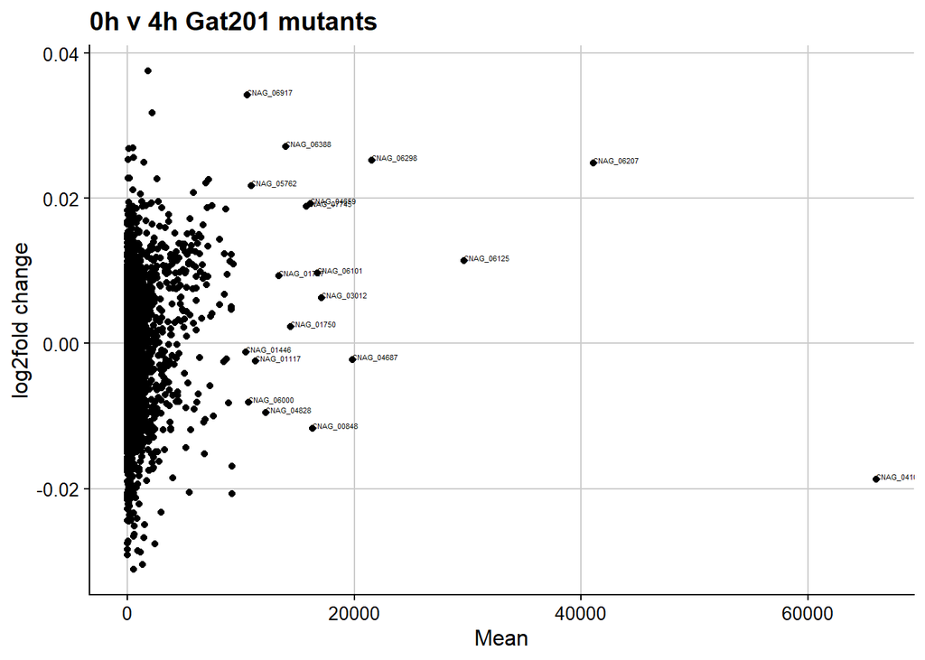

```r
readr::write_tsv(de_Gat201down_0_4, "~/Documents/GitHub/CryptoGat201RNASeq_draft/results_deseq_2/0v4Gat201mutdown_padj0p05.txt")
readr::write_lines(de_Gat201down_0_4$gene, "~/Documents/GitHub/CryptoGat201RNASeq_draft/results_deseq_2/0v4Gat201mutdown_padj0p05h_genesonly.txt")

plot_0_4<- qplot(x = baseMean, y = estimate, data = tresults_0_4, geom = "point")+
               geom_text(aes(label=ifelse(baseMean> 10000, (gene),'')),hjust=0,vjust=0, cex = 1.5, jitter = 0.5)+
               labs(x ="Mean", y= "log2fold change", title = "0h v 4h Gat201 mutants")
plot_0_4
```

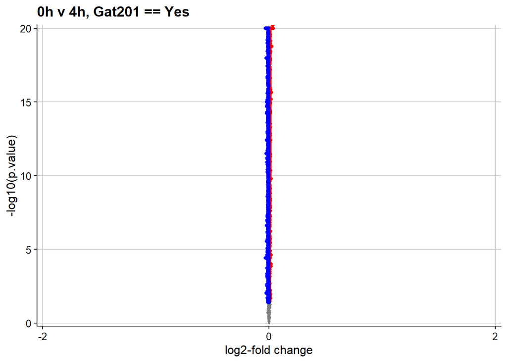

```r
volcano_0_4 <-
  ggplot(data = tresults_0_4, aes(x=estimate,y=-log10(p.value))) +
         geom_point(colour = "grey50",size = 0.5) +
         geom_point(data = de_Gat201up_0_4, colour = Gat201up_colour) +
         geom_point(data = de_Gat201down_0_4, colour = Gat201down_colour) +
         geom_text_repel(aes(label=ifelse(estimate < -1 & -log10(p.value)> 1.3, (gene),'')), size= 2, max.overlaps = getOption("ggrepel.max.overlaps", default = 15))+
         geom_text_repel(aes(label=ifelse(estimate > 1 & -log10(p.value)> 1.3, (gene),'')), size = 2, max.overlaps = getOption("ggrepel.max.overlaps", default = 15))+
         scale_y_continuous(breaks = c(0,5,10,15,20),
                            limits = c(0,20),
                            expand = c(0.01,0.01),
                            oob = scales::squish) +
        scale_x_continuous(breaks = seq(-2,2,2),
                            limits = c(-2,2),
                            expand = c(0.01,0.01),
                            oob = scales::squish) +
        labs(x = "log2-fold change",
        title = "0h v 4h, Gat201 == Yes")
volcano_0_4
```

```r
ggsave("~/Documents/GitHub/CryptoGat201RNASeq_draft/results_deseq_2/0v4Gat201.png",
       width = 5,height=5)
```

## 0h v 30 mins, WT

```r
samplesheet_0_30n <- samplesheet %>% filter(Time == "0" | Time == "30") %>%
                    filter(GAT201 == "No")
                    print(samplesheet_0_30n)
```

```
## # A tibble: 12 x 9
##    SampleID BioRep Media  Timepoint Group   Strain Condition  Time GAT201
##  * <chr>     <dbl> <chr>      <dbl> <chr>   <chr>  <chr>     <dbl> <fct>
##  1 29b           1 YPD            0 B_Y_0   B      Y             0 No
##  2 30            1 RPMI          30 B_R_30  B      R            30 No
##  3 33            2 YPD            0 B_Y_0   B      Y             0 No
##  4 34            2 RPMI          30 B_R_30  B      R            30 No
##  5 37            1 RPMI+S        30 B_RS_30 B      RS           30 No
##  6 40            2 RPMI+S        30 B_RS_30 B      RS           30 No
##  7 43            1 YPD            0 M_Y_0   M      Y             0 No
##  8 44            1 RPMI          30 M_R_30  M      R            30 No
##  9 47            2 YPD            0 M_Y_0   M      Y             0 No
## 10 48            2 RPMI          30 M_R_30  M      R            30 No
## 11 51            1 RPMI+S        30 M_RS_30 M      RS           30 No
## 12 54            2 RPMI+S        30 M_RS_30 M      RS           30 No
```

```r
counts_0_30n <-   dplyr::select(counts, samplesheet_0_30n$SampleID) %>%
                 magrittr::set_rownames(counts$Geneid)

dds_0_30n <- DESeqDataSetFromMatrix(countData = counts_0_30n,
                                 colData = samplesheet_0_30n,
                                 design = ~ Time)%>%
        DESeq()

resultsNames(dds_0_30n)
```

```
## [1] "Intercept" "Time"
```

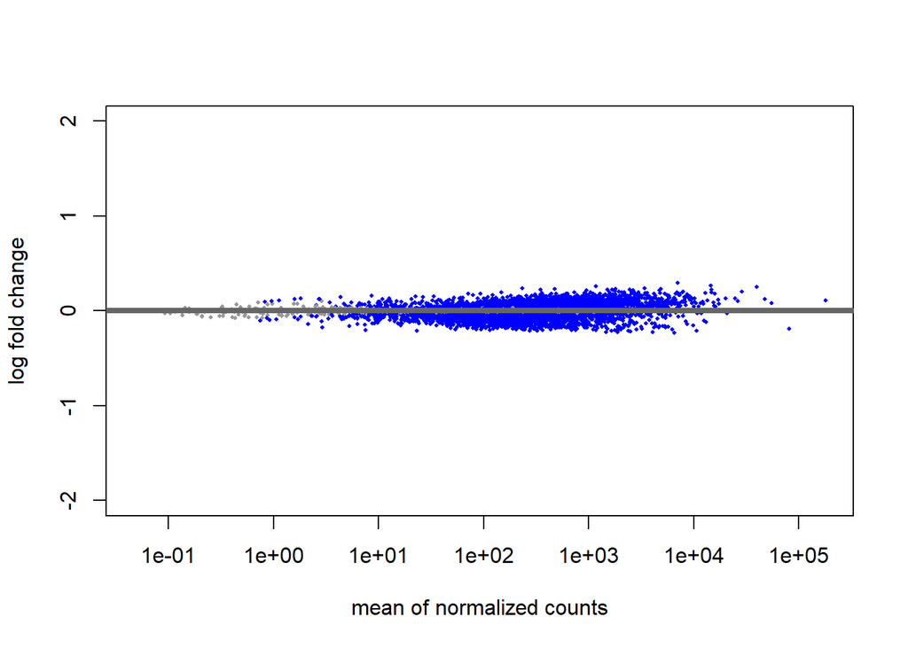

```r
results_0_30n <- results(dds_0_30n, name="Time")
plotMA(results_0_30n, ylim=c(-2,2))
```

```r
tresults_0_30n <- biobroom::tidy.DESeqResults(results_0_30n)
head(tresults_0_30n)
```

```
## # A tibble: 6 x 7
##   gene       baseMean estimate stderror statistic  p.value p.adjusted
##   <chr>         <dbl>    <dbl>    <dbl>     <dbl>    <dbl>      <dbl>
## 1 CNAG_00002    1408.  0.0560   0.00406    13.8   2.99e-43   1.50e-42
## 2 CNAG_00003     163. -0.0487   0.00592    -8.23  1.89e-16   4.61e-16
## 3 CNAG_00004     275.  0.00419  0.00543     0.773 4.40e- 1   4.76e- 1
## 4 CNAG_00005     571.  0.0203   0.00881     2.31  2.09e- 2   2.67e- 2
## 5 CNAG_00006     809. -0.0259   0.00417    -6.21  5.17e-10   1.01e- 9
## 6 CNAG_00007     512.  0.0917   0.00435    21.1   1.62e-98   2.54e-97
```

```r
tresults_0_30n %>%
dplyr::mutate(minus_log10_pvalue = -log10(p.value)) %>%
readr::write_tsv("~/Documents/GitHub/CryptoGat201RNASeq_draft/results_deseq_2/0v30nWT.txt")

de_WTup_0_30n <- dplyr::filter(tresults_0_30n, estimate > 0, p.adjusted < 0.05) %>%
              dplyr::arrange(desc(estimate))
de_WTup_0_30n
```

```
## # A tibble: 2,710 x 7
##    gene       baseMean estimate stderror statistic   p.value p.adjusted
##    <chr>         <dbl>    <dbl>    <dbl>     <dbl>     <dbl>      <dbl>
##  1 CNAG_05144    7048.    0.291  0.00954      30.5 4.14e-204  5.01e-202
##  2 CNAG_00979   14608.    0.269  0.00774      34.7 3.14e-264  9.67e-262
##  3 CNAG_06517    1181.    0.256  0.0105       24.3 7.38e-131  2.31e-129
##  4 CNAG_02775   39692.    0.250  0.00533      46.8 0          0
##  5 CNAG_00934     235.    0.240  0.0184       13.1 4.66e- 39  2.12e- 38
##  6 CNAG_04347    3415.    0.236  0.00648      36.4 1.48e-290  6.27e-288
##  7 CNAG_03878     476.    0.231  0.0124       18.6 1.38e- 77  1.42e- 76
##  8 CNAG_03975    1808.    0.228  0.00875      26.1 5.98e-150  2.70e-148
##  9 CNAG_05425    4887.    0.227  0.00856      26.5 3.93e-155  1.93e-153
## 10 CNAG_00895    1670.    0.226  0.00849      26.7 1.15e-156  5.92e-155
## # ... with 2,700 more rows
```

```r
readr::write_tsv(de_WTup_0_30n, "~/Documents/GitHub/CryptoGat201RNASeq_draft/results_deseq_2/0v30nWTup_padj0p05.txt")
readr::write_lines(de_WTup_0_30n$gene, "~/Documents/GitHub/CryptoGat201RNASeq_draft/results_deseq_2/0v30nWTup_padj0p05_genesonly.txt")

de_WTdown_0_30n <- dplyr::filter(tresults_0_30n, estimate < 0, p.adjusted < 0.05) %>%
                dplyr::arrange(estimate)
de_WTdown_0_30n
```

```
## # A tibble: 2,740 x 7
##    gene       baseMean estimate stderror statistic   p.value p.adjusted
##    <chr>         <dbl>    <dbl>    <dbl>     <dbl>     <dbl>      <dbl>
##  1 CNAG_06453   6573.    -0.235  0.00712    -33.0  2.69e-239  6.06e-237
##  2 CNAG_01534   4105.    -0.224  0.00685    -32.7  2.65e-234  5.44e-232
##  3 CNAG_06074   1456.    -0.223  0.00517    -43.1  0          0
##  4 CNAG_06169   1891.    -0.222  0.00601    -37.0  3.78e-300  2.13e-297
##  5 CNAG_01102   2514.    -0.222  0.00677    -32.8  3.38e-236  7.38e-234
##  6 CNAG_00091   2383.    -0.214  0.00400    -53.4  0          0
##  7 CNAG_03759     23.1   -0.214  0.0220      -9.71 2.80e- 22  8.08e- 22
##  8 CNAG_00834    323.    -0.213  0.00712    -30.0  1.43e-197  1.56e-195
##  9 CNAG_02899   1641.    -0.211  0.00433    -48.7  0          0
## 10 CNAG_01052    275.    -0.210  0.00824    -25.5  1.68e-143  6.69e-142
## # ... with 2,730 more rows
```

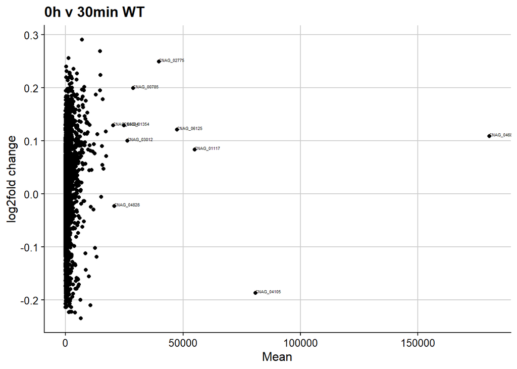

```r
readr::write_tsv(de_WTdown_0_30n, "~/Documents/GitHub/CryptoGat201RNASeq_draft/results_deseq_2/0v30nWTdown_padj0p05.txt")
readr::write_lines(de_WTdown_0_30n$gene, "~/Documents/GitHub/CryptoGat201RNASeq_draft/results_deseq_2/0v30nWTdown_padj0p05h_genesonly.txt")

plot_0_30n<- qplot(x = baseMean, y = estimate, data = tresults_0_30n, geom = "point")+
               geom_text(aes(label=ifelse(baseMean> 20000, (gene),'')),hjust=0,vjust=0, cex = 1.5, jitter = 0.5)+
               labs(x ="Mean", y= "log2fold change", title = "0h v 30min WT")
plot_0_30n
```

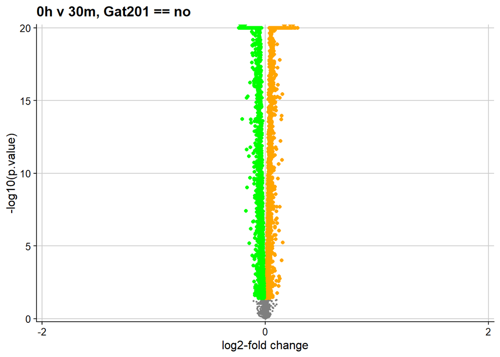

```r
volcano_0_30n <-
  ggplot(data = tresults_0_30n, aes(x=estimate,y=-log10(p.value))) +
         geom_point(colour = "grey50",size = 0.5) +
         geom_point(data = de_WTup_0_30n, colour = WTup_colour) +
         geom_point(data = de_WTdown_0_30n, colour = WTdown_colour) +
         geom_text_repel(aes(label=ifelse(estimate < -1 & -log10(p.value)> 1.3, (gene),'')), size= 2, max.overlaps = getOption("ggrepel.max.overlaps", default = 15))+
         geom_text_repel(aes(label=ifelse(estimate > 1 & -log10(p.value)> 1.3, (gene),'')), size = 2, max.overlaps = getOption("ggrepel.max.overlaps", default = 15))+
         scale_y_continuous(breaks = c(0,5,10,15,20),
                            limits = c(0,20),
                            expand = c(0.01,0.01),
                            oob = scales::squish) +
        scale_x_continuous(breaks = seq(-2,2,2),
                            limits = c(-2,2),
                            expand = c(0.01,0.01),
                            oob = scales::squish) +
        labs(x = "log2-fold change",
        title = "0h v 30m, Gat201 == no")
volcano_0_30n
```

```r
ggsave("~/Documents/GitHub/CryptoGat201RNASeq_draft/results_deseq_2/0v30nWT.png",
       width = 5,height=5)
```

## 0h v 2h, WT

```r
samplesheet_0_2n <- samplesheet %>% filter(Time == "0" | Time == "120") %>%
                    filter(GAT201 == "No")
                    print(samplesheet_0_2n)
```

```
## # A tibble: 12 x 9
##    SampleID BioRep Media  Timepoint Group    Strain Condition  Time GAT201
##  * <chr>     <dbl> <chr>      <dbl> <chr>    <chr>  <chr>     <dbl> <fct>
##  1 29b           1 YPD            0 B_Y_0    B      Y             0 No
##  2 31            1 RPMI         120 B_R_120  B      R           120 No
##  3 33            2 YPD            0 B_Y_0    B      Y             0 No
##  4 35            2 RPMI         120 B_R_120  B      R           120 No
##  5 38            1 RPMI+S       120 B_RS_120 B      RS          120 No
##  6 41            2 RPMI+S       120 B_RS_120 B      RS          120 No
##  7 43            1 YPD            0 M_Y_0    M      Y             0 No
##  8 45            1 RPMI         120 M_R_120  M      R           120 No
##  9 47            2 YPD            0 M_Y_0    M      Y             0 No
## 10 49            2 RPMI         120 M_R_120  M      R           120 No
## 11 52            1 RPMI+S       120 M_RS_120 M      RS          120 No
## 12 55            2 RPMI+S       120 M_RS_120 M      RS          120 No
```

```r
counts_0_2n <-   dplyr::select(counts, samplesheet_0_2n$SampleID) %>%
                 magrittr::set_rownames(counts$Geneid)

dds_0_2n <- DESeqDataSetFromMatrix(countData = counts_0_2n,
                                 colData = samplesheet_0_2n,
                                 design = ~ Time)%>%
        DESeq()

resultsNames(dds_0_2n)
```

```
## [1] "Intercept" "Time"
```

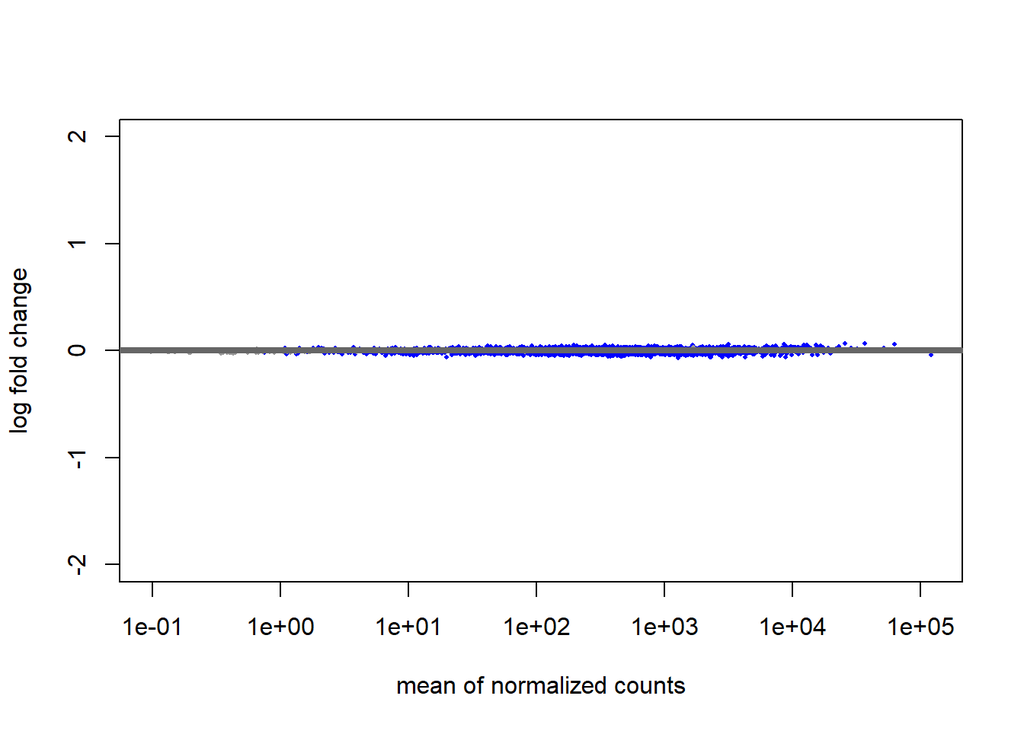

```r
results_0_2n <- results(dds_0_2n, name="Time")
plotMA(results_0_2n, ylim=c(-2,2))
```

```r
tresults_0_2n <- biobroom::tidy.DESeqResults(results_0_2n)
head(tresults_0_2n)
```

```
## # A tibble: 6 x 7
##   gene       baseMean estimate stderror statistic  p.value p.adjusted
##   <chr>         <dbl>    <dbl>    <dbl>     <dbl>    <dbl>      <dbl>
## 1 CNAG_00002     613. -0.00547 0.00119      -4.58 4.57e- 6   7.78e- 6
## 2 CNAG_00003     231. -0.0125  0.00128      -9.77 1.52e-22   5.40e-22
## 3 CNAG_00004     267. -0.00638 0.00109      -5.84 5.09e- 9   1.02e- 8
## 4 CNAG_00005     849.  0.00578 0.00159       3.64 2.74e- 4   4.15e- 4
## 5 CNAG_00006    1435. -0.00194 0.000971     -2.00 4.58e- 2   5.67e- 2
## 6 CNAG_00007     424.  0.0158  0.00117      13.4  3.43e-41   2.26e-40
```

```r
tresults_0_2n %>%
dplyr::mutate(minus_log10_pvalue = -log10(p.value)) %>%
readr::write_tsv("~/Documents/GitHub/CryptoGat201RNASeq_draft/results_deseq_2/0v2nWT.txt")

de_WTup_0_2n <- dplyr::filter(tresults_0_2n, estimate > 0, p.adjusted < 0.05) %>%
              dplyr::arrange(desc(estimate))
de_WTup_0_2n
```

```
## # A tibble: 2,705 x 7
##    gene       baseMean estimate stderror statistic   p.value p.adjusted
##    <chr>         <dbl>    <dbl>    <dbl>     <dbl>     <dbl>      <dbl>
##  1 CNAG_06388   25512.   0.0674  0.00231      29.2 9.10e-188  1.21e-185
##  2 CNAG_06298   36744.   0.0640  0.00178      35.9 7.93e-283  3.83e-280
##  3 CNAG_00895    3143.   0.0598  0.00384      15.6 1.28e- 54  1.26e- 53
##  4 CNAG_06207   62672.   0.0569  0.00179      31.7 8.79e-221  1.65e-218
##  5 CNAG_00979    8572.   0.0565  0.00410      13.8 3.38e- 43  2.35e- 42
##  6 CNAG_02235     196.   0.0546  0.00427      12.8 1.81e- 37  1.05e- 36
##  7 CNAG_00162   15311.   0.0526  0.00149      35.2 3.43e-271  1.22e-268
##  8 CNAG_05144    1664.   0.0511  0.00224      22.8 1.92e-115  6.96e-114
##  9 CNAG_06297   12882.   0.0506  0.00157      32.2 2.29e-227  4.99e-225
## 10 CNAG_03878     340.   0.0495  0.00284      17.4 6.62e- 68  8.80e- 67
## # ... with 2,695 more rows
```

```r
readr::write_tsv(de_WTup_0_2n, "~/Documents/GitHub/CryptoGat201RNASeq_draft/results_deseq_2/0v2nWTup_padj0p05.txt")
readr::write_lines(de_WTup_0_2n$gene, "~/Documents/GitHub/CryptoGat201RNASeq_draft/results_deseq_2/0v2nWTup_padj0p05_genesonly.txt")

de_WTdown_0_2n <- dplyr::filter(tresults_0_2n, estimate < 0, p.adjusted < 0.05) %>%
                dplyr::arrange(estimate)
de_WTdown_0_2n
```

```
## # A tibble: 2,725 x 7
##    gene       baseMean estimate stderror statistic   p.value p.adjusted
##    <chr>         <dbl>    <dbl>    <dbl>     <dbl>     <dbl>      <dbl>
##  1 CNAG_04459   1269.   -0.0671  0.00153    -44.0  0          0
##  2 CNAG_02118   4286.   -0.0654  0.00122    -53.6  0          0
##  3 CNAG_01919   8794.   -0.0628  0.00136    -46.3  0          0
##  4 CNAG_01827     19.8  -0.0626  0.00649     -9.65 4.99e- 22  1.74e- 21
##  5 CNAG_07308    774.   -0.0597  0.00187    -32.0  3.98e-224  8.16e-222
##  6 CNAG_03782   2839.   -0.0596  0.00166    -35.9  1.66e-282  7.50e-280
##  7 CNAG_02899   2311.   -0.0590  0.00156    -37.8  0          0
##  8 CNAG_06267   2260.   -0.0584  0.00174    -33.7  1.66e-248  4.88e-246
##  9 CNAG_01534   5840.   -0.0564  0.00166    -34.0  4.67e-253  1.44e-250
## 10 CNAG_02543    363.   -0.0557  0.00201    -27.7  7.47e-169  7.43e-167
## # ... with 2,715 more rows
```

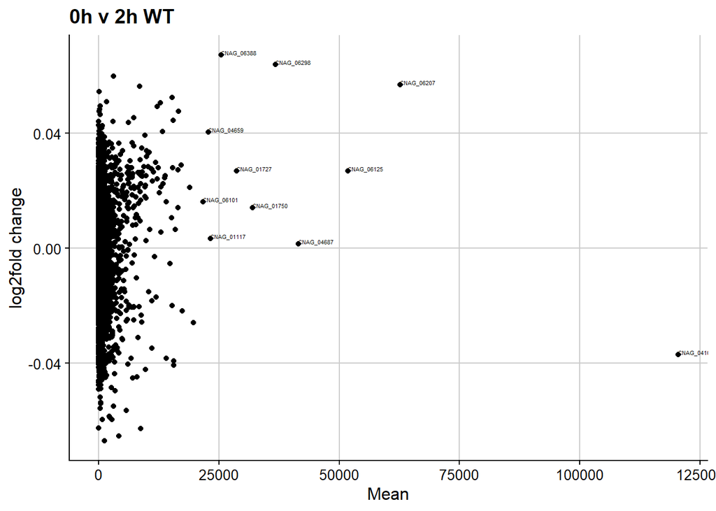

```r
readr::write_tsv(de_WTdown_0_2n, "~/Documents/GitHub/CryptoGat201RNASeq_draft/results_deseq_2/0v2nWTdown_padj0p05.txt")
readr::write_lines(de_WTdown_0_2n$gene, "~/Documents/GitHub/CryptoGat201RNASeq_draft/results_deseq_2/0v2nWTdown_padj0p05h_genesonly.txt")

plot_0_2n<- qplot(x = baseMean, y = estimate, data = tresults_0_2n, geom = "point")+
               geom_text(aes(label=ifelse(baseMean> 20000, (gene),'')),hjust=0,vjust=0, cex = 1.5, jitter = 0.5)+
               labs(x ="Mean", y= "log2fold change", title = "0h v 2h WT")
plot_0_2n
```

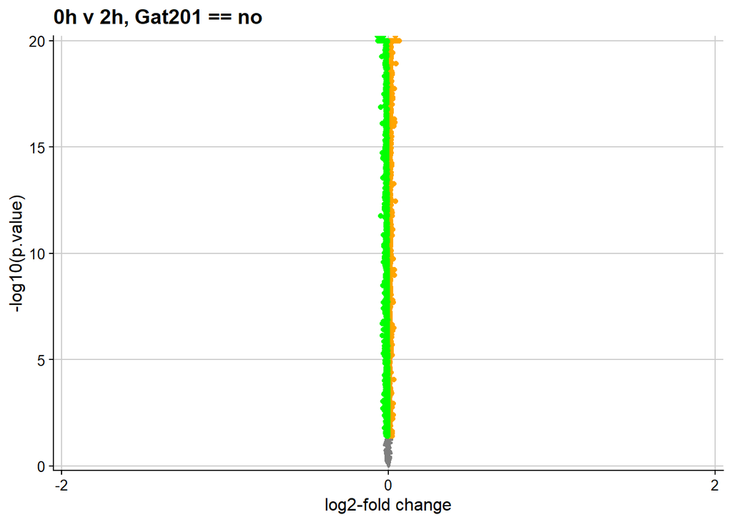

```r
volcano_0_2n <-
  ggplot(data = tresults_0_2n, aes(x=estimate,y=-log10(p.value))) +
         geom_point(colour = "grey50",size = 0.5) +
         geom_point(data = de_WTup_0_2n, colour = WTup_colour) +
         geom_point(data = de_WTdown_0_2n, colour = WTdown_colour) +
          geom_text_repel(aes(label=ifelse(estimate < -1 & -log10(p.value)> 1.3, (gene),'')), size= 2, max.overlaps = getOption("ggrepel.max.overlaps", default = 15))+
         geom_text_repel(aes(label=ifelse(estimate > 1 & -log10(p.value)> 1.3, (gene),'')), size = 2, max.overlaps = getOption("ggrepel.max.overlaps", default = 15))+
         scale_y_continuous(breaks = c(0,5,10,15,20),
                            limits = c(0,20),
                            expand = c(0.01,0.01),
                            oob = scales::squish) +
        scale_x_continuous(breaks = seq(-2,2,2),
                            limits = c(-2,2),
                            expand = c(0.01,0.01),
                            oob = scales::squish) +
        labs(x = "log2-fold change",
        title = "0h v 2h, Gat201 == no")
volcano_0_2n
```

```r
ggsave("~/Documents/GitHub/CryptoGat201RNASeq_draft/results_deseq_2/0v2nWT.png",
       width = 5,height=5)
```

## 0h v 4h, WT

```r
samplesheet_0_4n <- samplesheet %>% filter(Time == "0" | Time == "240") %>%
                    filter(GAT201 == "No")
                    print(samplesheet_0_4n)
```

```
## # A tibble: 12 x 9
##    SampleID BioRep Media  Timepoint Group    Strain Condition  Time GAT201
##  * <chr>     <dbl> <chr>      <dbl> <chr>    <chr>  <chr>     <dbl> <fct>
##  1 29b           1 YPD            0 B_Y_0    B      Y             0 No
##  2 32            1 RPMI         240 B_R_240  B      R           240 No
##  3 33            2 YPD            0 B_Y_0    B      Y             0 No
##  4 36            2 RPMI         240 B_R_240  B      R           240 No
##  5 39            1 RPMI+S       240 B_RS_240 B      RS          240 No
##  6 42            2 RPMI+S       240 B_RS_240 B      RS          240 No
##  7 43            1 YPD            0 M_Y_0    M      Y             0 No
##  8 46            1 RPMI         240 M_R_240  M      R           240 No
##  9 47            2 YPD            0 M_Y_0    M      Y             0 No
## 10 50            2 RPMI         240 M_R_240  M      R           240 No
## 11 53            1 RPMI+S       240 M_RS_240 M      RS          240 No
## 12 56            2 RPMI+S       240 M_RS_240 M      RS          240 No
```

```r
counts_0_4n <-   dplyr::select(counts, samplesheet_0_4n$SampleID) %>%
                 magrittr::set_rownames(counts$Geneid)

dds_0_4n <- DESeqDataSetFromMatrix(countData = counts_0_4n,
                                 colData = samplesheet_0_4n,
                                 design = ~ Time)%>%
        DESeq()

resultsNames(dds_0_4n)
```

```
## [1] "Intercept" "Time"
```

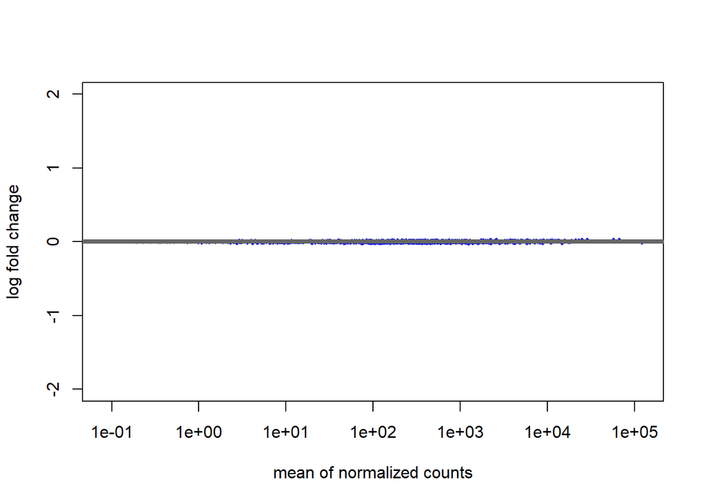

```r
results_0_4n <- results(dds_0_4n, name="Time")
plotMA(results_0_4n, ylim=c(-2,2))
```

```r
tresults_0_4n <- biobroom::tidy.DESeqResults(results_0_4n)
head(tresults_0_4n)
```

```
## # A tibble: 6 x 7
##   gene       baseMean  estimate stderror statistic  p.value p.adjusted
##   <chr>         <dbl>     <dbl>    <dbl>     <dbl>    <dbl>      <dbl>
## 1 CNAG_00002     498. -0.00498  0.000610     -8.17 3.13e-16   8.85e-16
## 2 CNAG_00003     189. -0.00936  0.000526    -17.8  8.33e-71   1.26e-69
## 3 CNAG_00004     223. -0.00516  0.000489    -10.5  5.59e-26   2.32e-25
## 4 CNAG_00005     483. -0.00194  0.000550     -3.52 4.24e- 4   6.21e- 4
## 5 CNAG_00006    1749.  0.000961 0.000434      2.21 2.68e- 2   3.36e- 2
## 6 CNAG_00007     390.  0.00742  0.000590     12.6  3.11e-36   1.85e-35
```

```r
tresults_0_4n %>%
dplyr::mutate(minus_log10_pvalue = -log10(p.value)) %>%
readr::write_tsv("~/Documents/GitHub/CryptoGat201RNASeq_draft/results_deseq_2/0v4nWT.txt")

de_WTup_0_4n <- dplyr::filter(tresults_0_4n, estimate > 0, p.adjusted < 0.05) %>%
              dplyr::arrange(desc(estimate))
de_WTup_0_4n
```

```
## # A tibble: 2,710 x 7
##    gene       baseMean estimate stderror statistic   p.value p.adjusted
##    <chr>         <dbl>    <dbl>    <dbl>     <dbl>     <dbl>      <dbl>
##  1 CNAG_06388   25201.   0.0337 0.00186       18.1 4.58e- 73  7.29e- 72
##  2 CNAG_06298   28597.   0.0306 0.00188       16.2 4.01e- 59  4.46e- 58
##  3 CNAG_06207   66867.   0.0289 0.00165       17.5 1.34e- 68  1.95e- 67
##  4 CNAG_04215    2618.   0.0284 0.000859      33.1 1.42e-239  5.33e-237
##  5 CNAG_00895    2238.   0.0279 0.00260       10.8 5.81e- 27  2.50e- 26
##  6 CNAG_06347   57620.   0.0274 0.00126       21.8 3.29e-105  1.09e-103
##  7 CNAG_02235     168.   0.0265 0.00205       12.9 3.68e- 38  2.32e- 37
##  8 CNAG_03716     191.   0.0250 0.00186       13.5 2.87e- 41  2.00e- 40
##  9 CNAG_00162   11299.   0.0245 0.00123       19.9 5.01e- 88  1.14e- 86
## 10 CNAG_05762   21072.   0.0242 0.000555      43.7 0          0
## # ... with 2,700 more rows
```

```r
readr::write_tsv(de_WTup_0_4n, "~/Documents/GitHub/CryptoGat201RNASeq_draft/results_deseq_2/0v4nWTup_padj0p05.txt")
readr::write_lines(de_WTup_0_4n$gene, "~/Documents/GitHub/CryptoGat201RNASeq_draft/results_deseq_2/0v4nWTup_padj0p05_genesonly.txt")

de_WTdown_0_4n <- dplyr::filter(tresults_0_4n, estimate < 0, p.adjusted < 0.05) %>%
                dplyr::arrange(estimate)
de_WTdown_0_4n
```

```
## # A tibble: 2,781 x 7
##    gene       baseMean estimate stderror statistic   p.value p.adjusted
##    <chr>         <dbl>    <dbl>    <dbl>     <dbl>     <dbl>      <dbl>
##  1 CNAG_04459   1254.   -0.0303 0.000993     -30.6 5.63e-205  1.15e-202
##  2 CNAG_03666   1600.   -0.0280 0.00104      -26.9 3.65e-159  3.05e-157
##  3 CNAG_02118   4262.   -0.0280 0.000790     -35.5 1.18e-275  7.99e-273
##  4 CNAG_02899   2283.   -0.0279 0.00116      -24.0 1.84e-127  9.09e-126
##  5 CNAG_02045    118.   -0.0276 0.00124      -22.3 6.04e-110  2.14e-108
##  6 CNAG_00490   1399.   -0.0273 0.000851     -32.0 2.57e-225  7.25e-223
##  7 CNAG_01671     93.8  -0.0264 0.00126      -21.0 3.79e- 98  1.07e- 96
##  8 CNAG_06172     76.5  -0.0262 0.00136      -19.3 9.05e- 83  1.83e- 81
##  9 CNAG_03782   2832.   -0.0257 0.000933     -27.6 2.23e-167  2.15e-165
## 10 CNAG_01827     19.9  -0.0257 0.00252      -10.2 2.46e- 24  9.58e- 24
## # ... with 2,771 more rows
```